# Desigualdades

Lucía Bartolomeu

2023-01-05

# Resumen

# Indicadores

Para calcular los indicadores, en primer lugar instalamos los paquetes y activamos las librerías que vamos a utilizar.

# Razón de mortalidad materna

- Se calcula como: Muertes maternas por provincia/ nacidos vivos por provincia *fac de expansión.
- Fuentes: nacidos vivos y registros de defunciones.
- Indicador construido para 2019 y 2020, construido por quinquenios (2015 a 2019 y 2016 a 2020)

### Comenzamos por calcular las muertes maternas

```r
#muertes maternas por provincia
#traer base mortalidad
base_mortalidad <- read.csv2("MINSAL-defunciones-2005-2020.csv", encoding="latin1", sep = ",")

#mirar variables
datatable(head(base_mortalidad),caption = "This is the table caption")
```

|  | anio | jurisdiccion_de_residencia_id | jurisdicion_residencia_nombre | cie10_casusa_id | lista_clasificacion | sexo_id | Sexo | grupo_edad | muerte_materna_id | muerte_materna_clasificacion | cantidad |
| --- | --- | --- | --- | --- | --- | --- | --- | --- | --- | --- | --- |
| 1 | 2007 | 10 | Catamarca | V13 | 105 ACCIDENTES DE TRANSPORTE | 1 | masculino | 04.15 a 24 |  |  | 1 |
| 2 | 2012 | 14 | Córdoba | C34 | 034 TUMOR MALIGNO DE LA TRAQUEA, DE LOS BRONQUIOS Y DEL PULMON | 1 | masculino | 10.75 y más |  |  | 5 |
| 3 | 2009 | 18 | Corrientes | K70 | 084 ENFERMEDAD ALCOHOLICA DEL HIGADO | 1 | masculino | 09.65 a 74 |  |  | 2 |
| 4 | 2014 | 10 | Catamarca | N19 | 090 ENFERMEDADES RENALES Y DEL URETER | 1 | masculino | 09.65 a 74 |  |  | 5 |
| 5 | 2012 | 18 | Corrientes | B24 | 020 ENFERMEDAD POR VIRUS DE INMUNODEFICIENCIA HUMANA | 1 | masculino | 11.Sín especificar |  |  | 1 |
| 6 | 2012 | 14 | Córdoba | C34 | 034 TUMOR MALIGNO DE LA TRAQUEA, DE LOS BRONQUIOS Y DEL PULMON | 1 | masculino | 07.45 a 54 |  |  | 1 |

```r
datatable(str(base_mortalidad))
```

```
## 'data.frame':    734616 obs. of  11 variables:
##  $ anio                         : int  2007 2012 2009 2014 2012 2012 2011 2013 2011 2009 ...
##  $ jurisdiccion_de_residencia_id: int  10 14 18 10 18 14 2 6 2 18 ...
##  $ jurisdicion_residencia_nombre: chr  "Catamarca" "Córdoba" "Corrientes" "Catamarca" ...
##  $ cie10_casusa_id              : chr  "V13" "C34" "K70" "N19" ...
##  $ lista_clasificacion          : chr  "105 ACCIDENTES DE TRANSPORTE" "034 TUMOR MALIGNO DE LA TRAQUEA,  DE LOS BRONQUIOS Y DEL PULMON" "084 ENFERMEDAD ALCOHOLICA DEL HIGADO" "090 ENFERMEDADES RENALES Y DEL URETER" ...
##  $ sexo_id                      : int  1 1 1 1 1 1 1 1 1 1 ...
##  $ Sexo                         : chr  "masculino" "masculino" "masculino" "masculino" ...
##  $ grupo_edad                   : chr  "04.15 a 24" "10.75 y más" "09.65 a 74" "09.65 a 74" ...
##  $ muerte_materna_id            : chr  "" "" "" "" ...
##  $ muerte_materna_clasificacion : chr  NA NA NA NA ...
##  $ cantidad                     : int  1 5 2 5 1 1 1 2 13 1 ...
```

[interactive table not shown]

```r
kable(table(base_mortalidad$sexo_id))
```

| Var1 | Freq |
| --- | --- |
| 1 | 404912 |
| 2 | 325066 |
| 3 | 193 |
| 9 | 4445 |

```r
kable(table(base_mortalidad$muerte_materna_clasificacion))
```

| Var1 | Freq |
| --- | --- |
| muerte materna | 3520 |
| muerte materna tardia | 326 |

```r
#incluir muerte materna tardía?
#descriptivo quinquenios
base_mortalidad_materna_quinquenios <- base_mortalidad %>%
  filter(muerte_materna_clasificacion == "muerte materna" |
         muerte_materna_clasificacion == "muerte materna tardia") %>%
  mutate(quinquenio = case_when(
               between(anio, 2006,2010)~ "2006 - 2010",
                      between(anio, 2011,2015)~ "2011 - 2015",
                      between(anio, 2016,2020)~ "2016 - 2020",
                      TRUE~ NA_character_
                                          )) %>%
                    filter(!is.na(quinquenio)) %>%
    group_by(quinquenio,jurisdicion_residencia_nombre) %>%
  summarise(suma_quinquenio= sum(cantidad),mean=suma_quinquenio/5) %>% ###cambie la forma de clacular el promedio, si no se entendio preguntame
  ungroup()
datatable(base_mortalidad_materna_quinquenios)
```

|  | quinquenio | jurisdicion_residencia_nombre | suma_quinquenio | mean |
| --- | --- | --- | --- | --- |
| 1 | 2006 - 2010 | Buenos Aires | 532 | 106.4 |
| 2 | 2006 - 2010 | Catamarca | 23 | 4.6 |
| 3 | 2006 - 2010 | Chaco | 109 | 21.8 |
| 4 | 2006 - 2010 | Chubut | 21 | 4.2 |
| 5 | 2006 - 2010 | Ciudad Autónoma de Buenos Aires | 41 | 8.2 |
| 6 | 2006 - 2010 | Córdoba | 113 | 22.6 |
| 7 | 2006 - 2010 | Corrientes | 62 | 12.4 |
| 8 | 2006 - 2010 | Entre Ríos | 70 | 14 |
| 9 | 2006 - 2010 | Formosa | 93 | 18.6 |
| 10 | 2006 - 2010 | Jujuy | 56 | 11.2 |

[output cut: 67 more lines]

Se presenta un gráfico descriptivo del número de muertes maternas según quinquenio por provincia.

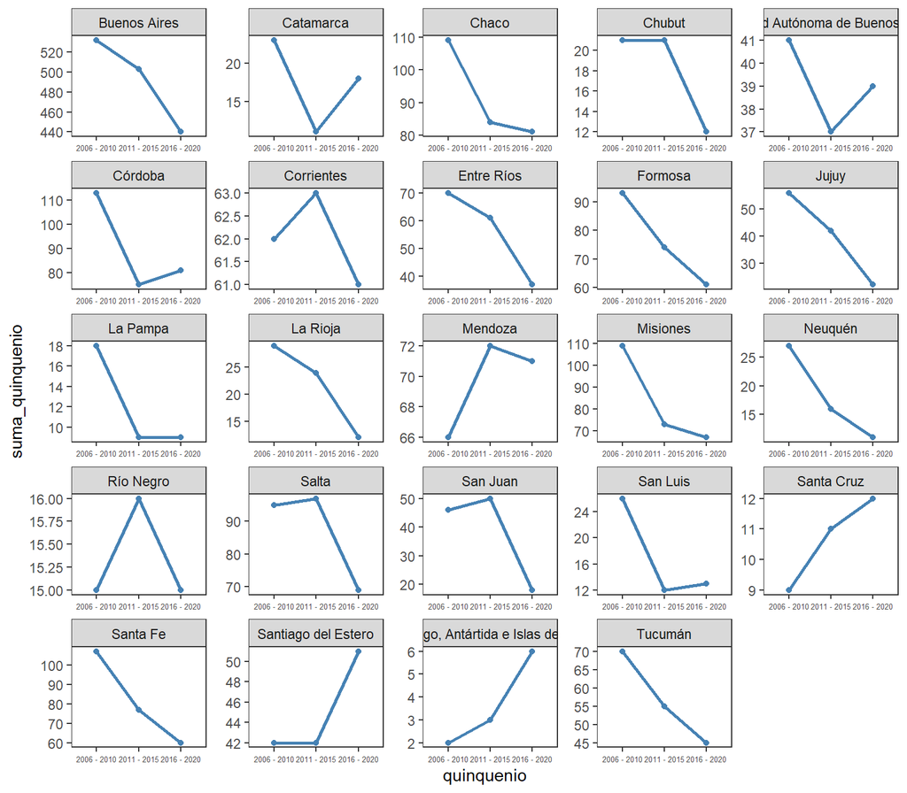

```r
base_mortalidad_materna_quinquenios$quinquenio <- factor(base_mortalidad_materna_quinquenios$quinquenio,
                                                          levels= c("2006 - 2010", "2011 - 2015", "2016 - 2020"))

ggplot(filter(base_mortalidad_materna_quinquenios,!is.na(jurisdicion_residencia_nombre),
                                                         jurisdicion_residencia_nombre!="Sin Información"),
       aes(quinquenio, suma_quinquenio, group=1))+
  geom_line(color = "steelblue",size = 1) +
  geom_point(color="steelblue") +
  facet_wrap(~ jurisdicion_residencia_nombre,scales="free",ncol=5)+
  theme_test()+
  theme(
    axis.text.x = element_text(size=5)
  )
```

```r
#quinquenio 2015-2019
base_mortalidad_materna_1519 <- base_mortalidad %>%
  filter(muerte_materna_clasificacion == "muerte materna" |
         muerte_materna_clasificacion == "muerte materna tardia") %>%
  mutate(quinquenio = case_when(
               between(anio, 2015,2019)~ "2015 - 2019",
                     TRUE~ NA_character_)) %>%
  filter(!is.na(quinquenio)) %>%
    group_by(quinquenio,jurisdicion_residencia_nombre) %>%
  summarise(suma_quinquenio= sum(cantidad),mean=suma_quinquenio/5) %>%
  filter(jurisdicion_residencia_nombre!="Sin Información",!is.na(jurisdicion_residencia_nombre))
base_mortalidad_materna_1519_tot <- base_mortalidad %>%
  filter(muerte_materna_clasificacion == "muerte materna" |
         muerte_materna_clasificacion == "muerte materna tardia") %>%
  mutate(quinquenio = case_when(
               between(anio, 2015,2019)~ "2015 - 2019",
                     TRUE~ NA_character_)) %>%
  filter(!is.na(quinquenio)) %>%
    group_by(quinquenio) %>%
  summarise(suma_quinquenio= sum(cantidad),mean=suma_quinquenio/5)

base_mortalidad_materna_1519_tot$jurisdicion_residencia_nombre <- "Total pais"
base_mortalidad_materna_1519_tot <- select(base_mortalidad_materna_1519_tot,"quinquenio" , "jurisdicion_residencia_nombre","suma_quinquenio","mean")

base_mortalidad_materna_1519 <- rbind(base_mortalidad_materna_1519,base_mortalidad_materna_1519_tot)

datatable(base_mortalidad_materna_1519, caption = "Promedio de muertes maternas en quinquenio 15-19 por provincias")
```

|  | quinquenio | jurisdicion_residencia_nombre | suma_quinquenio | mean |
| --- | --- | --- | --- | --- |
| 1 | 2015 - 2019 | Buenos Aires | 487 | 97.4 |
| 2 | 2015 - 2019 | Catamarca | 16 | 3.2 |
| 3 | 2015 - 2019 | Chaco | 86 | 17.2 |
| 4 | 2015 - 2019 | Chubut | 14 | 2.8 |
| 5 | 2015 - 2019 | Ciudad Autónoma de Buenos Aires | 34 | 6.8 |
| 6 | 2015 - 2019 | Córdoba | 82 | 16.4 |
| 7 | 2015 - 2019 | Corrientes | 59 | 11.8 |
| 8 | 2015 - 2019 | Entre Ríos | 44 | 8.8 |
| 9 | 2015 - 2019 | Formosa | 65 | 13 |
| 10 | 2015 - 2019 | Jujuy | 24 | 4.8 |

[output cut: 15 more lines]

```r
#quinquenio 2016-2020
base_mortalidad_materna_1620 <- base_mortalidad %>%
  filter(muerte_materna_clasificacion == "muerte materna" |
         muerte_materna_clasificacion == "muerte materna tardia") %>%
  mutate(quinquenio = case_when(
               between(anio, 2016,2020)~ "2016 - 2020",
                     FALSE~ NA_character_
                                          )) %>%
                    filter(!is.na(quinquenio)) %>%
    group_by(quinquenio,jurisdicion_residencia_nombre) %>%
  summarise(suma_quinquenio= sum(cantidad),mean=suma_quinquenio/5) %>%
   filter(jurisdicion_residencia_nombre!="Sin Información",!is.na(jurisdicion_residencia_nombre))
base_mortalidad_materna_1620_tot <- base_mortalidad %>%
  filter(muerte_materna_clasificacion == "muerte materna" |
         muerte_materna_clasificacion == "muerte materna tardia") %>%
  mutate(quinquenio = case_when(
               between(anio, 2015,2019)~ "2015 - 2019",
                     TRUE~ NA_character_)) %>%
  filter(!is.na(quinquenio)) %>%
    group_by(quinquenio) %>%
  summarise(suma_quinquenio= sum(cantidad),mean=suma_quinquenio/5)

base_mortalidad_materna_1620_tot$jurisdicion_residencia_nombre <- "Total pais"
base_mortalidad_materna_1620_tot <- select(base_mortalidad_materna_1620_tot,"quinquenio" , "jurisdicion_residencia_nombre","suma_quinquenio","mean")

base_mortalidad_materna_1620 <- rbind(base_mortalidad_materna_1620,base_mortalidad_materna_1519_tot)

datatable(base_mortalidad_materna_1620, caption = "Promedio de muertes maternas en quinquenio 16-20 por provincias")
```

|  | quinquenio | jurisdicion_residencia_nombre | suma_quinquenio | mean |
| --- | --- | --- | --- | --- |
| 1 | 2016 - 2020 | Buenos Aires | 440 | 88 |
| 2 | 2016 - 2020 | Catamarca | 18 | 3.6 |
| 3 | 2016 - 2020 | Chaco | 81 | 16.2 |
| 4 | 2016 - 2020 | Chubut | 12 | 2.4 |
| 5 | 2016 - 2020 | Ciudad Autónoma de Buenos Aires | 39 | 7.8 |
| 6 | 2016 - 2020 | Córdoba | 81 | 16.2 |
| 7 | 2016 - 2020 | Corrientes | 61 | 12.2 |
| 8 | 2016 - 2020 | Entre Ríos | 37 | 7.4 |
| 9 | 2016 - 2020 | Formosa | 61 | 12.2 |
| 10 | 2016 - 2020 | Jujuy | 22 | 4.4 |

[output cut: 15 more lines]

Luego se calculan los nacidos vivos, mismo período o jurisdicciones

```r
#nacidos vivos por provincia
#traer base nacidos vivos
base_nacidos_vivos <- read.csv2("MINSAL - Nacidos vivos 2005-2020 jurisdicción residencia de la madre.csv", encoding="latin1", sep = ",")

#mirar variables
#str(base_nacidos_vivos)

#descriptivo quinquenios
base_nacidos_vivos_quinquenios <- base_nacidos_vivos %>%
  mutate(quinquenio = case_when(
               between(anio, 2006,2010)~ "2006 - 2010",
                      between(anio, 2011,2015)~ "2011 - 2015",
                      between(anio, 2016,2020)~ "2016 - 2020",
                      FALSE~ NA_character_
                                          )) %>%
                    filter(!is.na(quinquenio)) %>%
    group_by(quinquenio,jurisdicion_residencia_nombre) %>%
  summarise(suma_quinquenio= sum(nacimientos_cantidad),mean=suma_quinquenio/5) %>%
   filter(jurisdicion_residencia_nombre!="Sin Información",!is.na(jurisdicion_residencia_nombre)) %>%
  ungroup(quinquenio)
#quinquenio 2015-2019
base_nacidos_vivos_1519 <- base_nacidos_vivos %>%
  mutate(quinquenio = case_when(
               between(anio, 2015,2019)~ "2015 - 2019",
                     FALSE~ NA_character_
                                          )) %>%
                    filter(!is.na(quinquenio)) %>%
    group_by(quinquenio,jurisdicion_residencia_nombre) %>%
  summarise(suma_quinquenio= sum(nacimientos_cantidad),mean=suma_quinquenio/5) %>%
   filter(jurisdicion_residencia_nombre!="Sin Información",!is.na(jurisdicion_residencia_nombre)) %>%
  ungroup(quinquenio)
#agregto to pais

base_nacidos_vivos_1519_tot <- base_nacidos_vivos %>%
  mutate(quinquenio = case_when(
               between(anio, 2015,2019)~ "2015 - 2019",
                     FALSE~ NA_character_
                                          )) %>%
                    filter(!is.na(quinquenio)) %>%
    group_by(quinquenio) %>%
  summarise(suma_quinquenio= sum(nacimientos_cantidad),mean=suma_quinquenio/5) %>%
  mutate(jurisdicion_residencia_nombre="Total pais") %>%
  select("quinquenio", "jurisdicion_residencia_nombre", "suma_quinquenio","mean")

base_nacidos_vivos_1519 <- rbind(base_nacidos_vivos_1519,base_nacidos_vivos_1519_tot)

#quinquenio 2016-2020
base_nacidos_vivos_1620 <- base_nacidos_vivos %>%
  mutate(quinquenio = case_when(
               between(anio, 2016,2020)~ "2016 - 2020",
                     FALSE~ NA_character_
                                          )) %>%
                    filter(!is.na(quinquenio)) %>%
    group_by(quinquenio,jurisdicion_residencia_nombre) %>%
  summarise(suma_quinquenio= sum(nacimientos_cantidad),mean=suma_quinquenio/5) %>%
   filter(jurisdicion_residencia_nombre!="Sin Información",!is.na(jurisdicion_residencia_nombre)) %>%
  ungroup(quinquenio)
#agregto to pais

base_nacidos_vivos_1620_tot <- base_nacidos_vivos %>%
  mutate(quinquenio = case_when(
               between(anio, 2015,2019)~ "2015 - 2019",
                     FALSE~ NA_character_
                                          )) %>%
                    filter(!is.na(quinquenio)) %>%
    group_by(quinquenio) %>%
  summarise(suma_quinquenio= sum(nacimientos_cantidad),mean=suma_quinquenio/5) %>%
  mutate(jurisdicion_residencia_nombre="Total pais") %>%
  select("quinquenio", "jurisdicion_residencia_nombre", "suma_quinquenio","mean")

base_nacidos_vivos_1620 <- rbind(base_nacidos_vivos_1620,base_nacidos_vivos_1620_tot)
```

### Finalmente, calculo la razón de mortalidad materna

```r
###razón de mortalidad materna utilizando suma de nacidos vivos como denominador de suma de mm y promedio con promedio

#AÑO 2019
unidos_2019 <- left_join(base_mortalidad_materna_1519, base_nacidos_vivos_1519,
              by = c("jurisdicion_residencia_nombre" = "jurisdicion_residencia_nombre", "quinquenio" = "quinquenio"))

unidos_2020 <- left_join(base_mortalidad_materna_1620, base_nacidos_vivos_1620,
              by = c("jurisdicion_residencia_nombre" = "jurisdicion_residencia_nombre", "quinquenio" = "quinquenio"))

RMM_2019 <- unidos_2019 %>%
  mutate(RMM_suma_19 = round(suma_quinquenio.x/suma_quinquenio.y*100000,1)) %>%
  mutate(RMM_mean_19 = mean.x/mean.y*100000) %>%
  ungroup(quinquenio)


datatable(select(RMM_2019,"jurisdicion_residencia_nombre" ,"RMM_suma_19"),caption = "RMM por provincia, año 2019")
```

|  | jurisdicion_residencia_nombre | RMM_suma_19 |
| --- | --- | --- |
| 1 | Buenos Aires | 37.4 |
| 2 | Catamarca | 49.5 |
| 3 | Chaco | 72.8 |
| 4 | Chubut | 31.2 |
| 5 | Ciudad Autónoma de Buenos Aires | 18.2 |
| 6 | Córdoba | 29.9 |
| 7 | Corrientes | 59.8 |
| 8 | Entre Ríos | 40.6 |
| 9 | Formosa | 113.3 |
| 10 | Jujuy | 40.3 |

[output cut: 15 more lines]

```r
RMM_2020 <- unidos_2020%>%
  mutate(RMM_suma_20 = round(suma_quinquenio.x/suma_quinquenio.y*100000,1)) %>%
  mutate(RMM_mean_20 = mean.x/mean.y*100000) %>%
  ungroup(quinquenio)

datatable(select(RMM_2020,"jurisdicion_residencia_nombre" ,"RMM_suma_20"),caption = "RMM por provincia, año 2020")
```

|  | jurisdicion_residencia_nombre | RMM_suma_20 |
| --- | --- | --- |
| 1 | Buenos Aires | 36.5 |
| 2 | Catamarca | 59.1 |
| 3 | Chaco | 73.2 |
| 4 | Chubut | 28.6 |
| 5 | Ciudad Autónoma de Buenos Aires | 22.5 |
| 6 | Córdoba | 31.1 |
| 7 | Corrientes | 64.5 |
| 8 | Entre Ríos | 36.4 |
| 9 | Formosa | 112.5 |
| 10 | Jujuy | 39.7 |

[output cut: 15 more lines]

```r
write_xlsx(RMM_2019,"RMM2019.xlsx")
write_xlsx(RMM_2020,"RMM2020.xlsx")
```

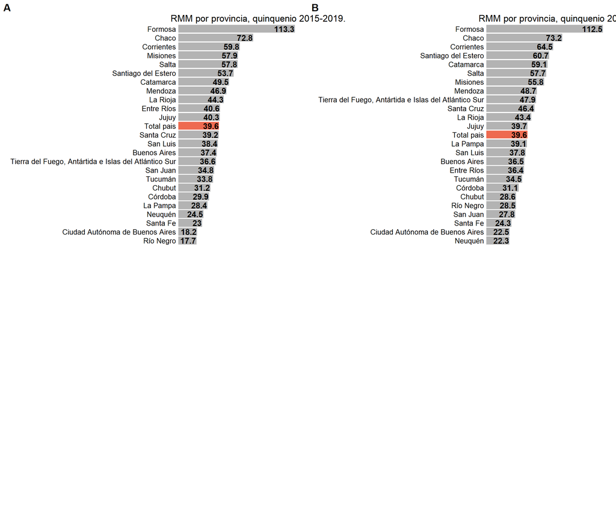

```r
#bar plot
plot1 <- RMM_2019 %>% mutate(
    color = case_when(
      row_number() == 25 ~ "coral2",
      ## all others should be gray
      TRUE ~ "gray70"
    ) ) %>%
   ggplot(aes(x = RMM_mean_19, y = fct_reorder(jurisdicion_residencia_nombre,RMM_mean_19), fill = color)) +
  geom_col() +
  geom_text(
    aes(label = round(RMM_mean_19,1)),
    hjust = 1, nudge_x = -.5,
    size = 4, fontface = "bold" ) +
  ## reduce spacing between labels and bars
  scale_x_continuous(expand = c(.02, .02)) +
  scale_fill_identity(guide = "none") +
  labs(title = "RMM por provincia, quinquenio 2015-2019.")+
  ## get rid of all elements except y axis labels + adjust plot margin
  theme_void() +
  theme(axis.text.y = element_text(size = 10, hjust = 1),
        plot.title = element_text(hjust = 0.1),
        plot.margin = margin(rep(15, 4)))

#bar plor a este grafco hacerlo con la tasa

plot2 <-  RMM_2020 %>% mutate(
    color = case_when(
      jurisdicion_residencia_nombre == "Total pais" ~ "coral2",
      ## all others should be gray
      TRUE ~ "gray70"
    ) ) %>%
   ggplot(aes(x = RMM_mean_20, y = fct_reorder(jurisdicion_residencia_nombre,RMM_mean_20), fill = color)) +
  geom_col() +
  geom_text(
    aes(label = round(RMM_mean_20,1)),
    hjust = 1, nudge_x = -.5,
    size = 4, fontface = "bold" ) +
  ## reduce spacing between labels and bars
  scale_x_continuous(expand = c(.02, .02)) +
  scale_fill_identity(guide = "none") +
  labs(title = "RMM por provincia, quinquenio 2016-2020.")+
  ## get rid of all elements except y axis labels + adjust plot margin
  theme_void() +
  theme(axis.text.y = element_text(size = 10, hjust = 1),
        plot.title = element_text(hjust = 0.1),
        plot.margin = margin(rep(15, 4)))

ggarrange(plot1, plot2,
          labels = c("A", "B"),
          ncol = 2, nrow = 2)
```

# % de nacidos vivos con bajo peso al nacer:

- Se calcula como: Número de nacidos vivos con bajo peso de un año y prov/numero total de nacidos vivos de un año y prov.
- Fuentes: base nacidos vivos
- Indicador construido para 2019 y 2020
1. Se realizó el cálculo de cantidad de niños con bajo peso al nacer y la cantidad de niños sin bajo peso al nacer

```r
base_nacidos_vivos <- read.csv2("MINSAL - Nacidos vivos 2005-2020 jurisdicción residencia de la madre.csv", encoding="latin1", sep = ",")

#mirar variables
str(base_nacidos_vivos)
```

```
## 'data.frame':    497974 obs. of  12 variables:
##  $ anio                         : int  2005 2005 2005 2005 2005 2017 2017 2005 2005 2005 ...
##  $ jurisdiccion_de_residencia_id: int  2 2 2 2 2 22 22 2 2 2 ...
##  $ jurisdicion_residencia_nombre: chr  "Ciudad Autónoma de Buenos Aires" "Ciudad Autónoma de Buenos Aires" "Ciudad Autónoma de Buenos Aires" "Ciudad Autónoma de Buenos Aires" ...
##  $ edad_madre_grupo             : chr  "5.30 a 34" "5.30 a 34" "4.25 a 29" "5.30 a 34" ...
##  $ instruccion_madre            : chr  "4.Secundaria/Polimodal Incompleta" "3.Primaria/C. EGB Completa" "5.Secundaria/Polimodal Completa" "4.Secundaria/Polimodal Incompleta" ...
##  $ tipo_de_parto_id             : int  1 1 1 1 1 1 1 1 1 1 ...
##  $ tipo_de_parto_nombre         : chr  "Simple" "Simple" "Simple" "Simple" ...
##  $ semana_gestacion             : chr  "4.28 a 31" "4.28 a 31" "4.28 a 31" "5.32 a 36" ...
##  $ intervalo_peso_al_nacer      : chr  "4.1500 a 1999" "2.500 a 999" "3.1000 a 1499" "4.1500 a 1999" ...
##  $ sexo_id                      : int  1 1 1 1 1 1 1 1 1 1 ...
##  $ Sexo                         : chr  "masculino" "masculino" "masculino" "masculino" ...
##  $ nacimientos_cantidad         : int  1 2 6 5 1 11 74 3 12 4 ...
```

```r
unique(base_nacidos_vivos$intervalo_peso_al_nacer)
```

```
## [1] "4.1500 a 1999"     "2.500 a 999"       "3.1000 a 1499"
## [4] "5.2000 a 2499"     "6.2500 a 2999"     "8.De 3500 y más"
## [7] "7.3000 a 3499"     "9.Sin especificar" "1.Menor de 500"
```

```r
indicador_bajopesoalnacer <- base_nacidos_vivos %>%
  mutate(bp = case_when(
    intervalo_peso_al_nacer == "1.Menor de 500" |
      intervalo_peso_al_nacer == "2.500 a 999"  |
      intervalo_peso_al_nacer == "3.1000 a 1499" |
      intervalo_peso_al_nacer ==  "4.1500 a 1999" |
      intervalo_peso_al_nacer ==  "5.2000 a 2499" ~ "si",
      TRUE~ "no")) %>%
  dplyr::filter(anio == "2019" | anio == "2020") %>%
  select(anio, jurisdicion_residencia_nombre, nacimientos_cantidad, bp) %>%
  group_by(anio, jurisdicion_residencia_nombre, bp) %>%
  dplyr::summarise(casos=sum(nacimientos_cantidad)) %>%
  pivot_wider(names_from = bp, values_from = casos) %>%
  mutate(indicador = round(si/(no+si)*100,2))
```

```
## You can override using the `.groups` argument.
```

```r
datatable(filter(indicador_bajopesoalnacer, !is.na(jurisdicion_residencia_nombre)),
          filter = 'top',
          elementId = NULL,
          options = list(
  searching = FALSE,
  pageLength = 5,
  lengthMenu = c(5, 10, 15, 20)
)

          )
```

|  | anio | jurisdicion_residencia_nombre | no | si | indicador |
| --- | --- | --- | --- | --- | --- |
| 1 | 2019 | Buenos Aires | 210156 | 17440 | 7.66 |
| 2 | 2019 | Catamarca | 5298 | 435 | 7.59 |
| 3 | 2019 | Chaco | 20366 | 1810 | 8.16 |
| 4 | 2019 | Chubut | 7354 | 507 | 6.45 |
| 5 | 2019 | Ciudad Autónoma de Buenos Aires | 31212 | 2769 | 8.15 |
| 6 | 2019 | Córdoba | 47275 | 3654 | 7.17 |
| 7 | 2019 | Corrientes | 16732 | 1412 | 7.78 |
| 8 | 2019 | Entre Ríos | 17709 | 1523 | 7.92 |
| 9 | 2019 | Formosa | 9441 | 809 | 7.89 |
| 10 | 2019 | Jujuy | 9668 | 684 | 6.61 |

[output cut: 40 more lines]

```r
write_xlsx(indicador_bajopesoalnacer,"indicador_bajopesoalnacer.xlsx")
```

# Tasa de mortalidad infantil

```r
db_mort_infantil <- read.csv("tasa-mortalidad-infantil-deis-1990-2020.csv", sep=";")
names(db_mort_infantil)
```

```
##  [1] "indice_tiempo"
##  [2] "mortalidad_infantil_argentina"
##  [3] "mortalidad_infantil_caba"
##  [4] "mortalidad_infantil_buenosaires"
##  [5] "mortalidad_infantil_catamarca"
##  [6] "mortalidad_infantil_cordoba"
##  [7] "mortalidad_infantil_corrientes"
##  [8] "mortalidad_infantil_chaco"
##  [9] "mortalidad_infantil_chubut"
## [10] "mortalidad_infantil_entrerios"
## [11] "mortalidad_infantil_formosa"
## [12] "mortalidad_infantil_jujuy"
## [13] "mortalidad_infantil_lapampa"
## [14] "mortalidad_infantil_larioja"
## [15] "mortalidad_infantil_mendoza"
## [16] "mortalidad_infantil_misiones"
## [17] "mortalidad_infantil_neuquen"
## [18] "mortalidad_infantil_rionegro"
## [19] "mortalidad_infantil_salta"
## [20] "mortalidad_infantil_sanjuan"
## [21] "mortalidad_infantil_sanluis"
## [22] "mortalidad_infantil_santacruz"
## [23] "mortalidad_infantil_santafe"
## [24] "mortalidad_infantil_santiagodelestero"
## [25] "mortalidad_infantil_tucuman"
## [26] "mortalidad_infantil_tierradelfuego"
```

```r
class(db_mort_infantil$indice_tiempo)
```

```
## [1] "character"
```

```r
db_mort_infantil$indice_tiempo <- dmy(db_mort_infantil$indice_tiempo)
class(db_mort_infantil$indice_tiempo)
```

```
## [1] "Date"
```

```r
db_mort_infantil2 <- db_mort_infantil %>%
                    mutate(ano=year(indice_tiempo)) %>%
                    gather(key = "provincia", value = "mort_infantil",2:26) %>%
                    mutate(trienio= case_when(
                      between(ano, 2015,2017)~ "2015 - 2017",
                      between(ano, 2018,2020)~ "2018 - 2020",
                      between(ano, 2012,2014)~ "2012 - 2014",
                      FALSE~ NA_character_
                                          )) %>%

                    filter(!is.na(trienio)) %>%

  group_by(trienio,provincia ) %>%
  summarise(promedio= round(mean(mort_infantil),2)) %>%
  ungroup()
```

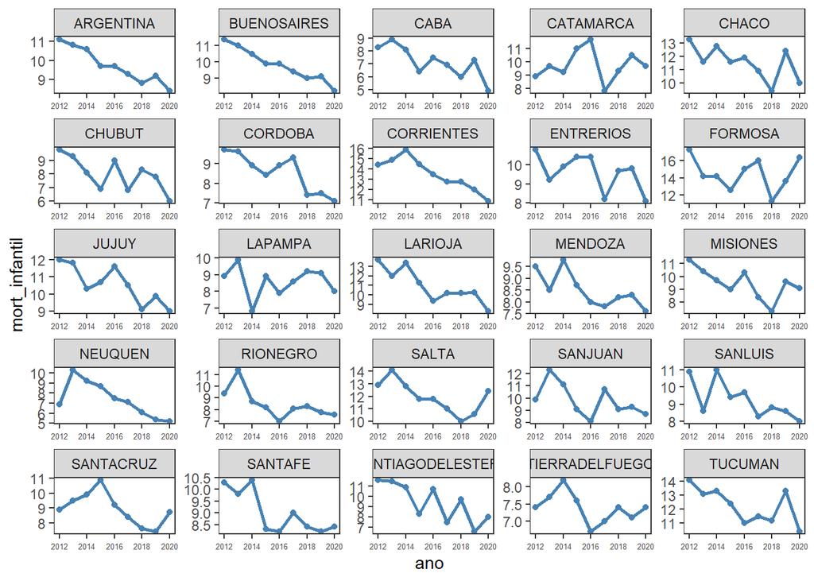

```r
###grafico tendencia

db_mort_infantil %>%
                    mutate(ano=year(indice_tiempo)) %>%
                    gather(key = "provincia", value = "mort_infantil",2:26) %>%
                    mutate(trienio= case_when(
                      between(ano, 2015,2017)~ "2015 - 2017",
                      between(ano, 2018,2020)~ "2018 - 2020",
                      between(ano, 2012,2014)~ "2012 - 2014",
                      FALSE~ NA_character_
                                          )) %>%
                    filter(!is.na(trienio)) %>%
  mutate(provincia=str_to_upper(str_remove(provincia,"mortalidad_infantil_"))) %>%
  ggplot(aes(ano, mort_infantil, group=1))+
  geom_line(color = "steelblue",size = 1) +
  geom_point(color="steelblue") +
  facet_wrap(~ provincia,scales="free",ncol=5)+
  theme_test()+
  theme(
    axis.text.x = element_text(size=5)
  )
```

```r
datatable(filter(db_mort_infantil2, !is.na(provincia)),
          filter = 'top',
          elementId = NULL,
          options = list(
  searching = FALSE,
   searchHighlight = TRUE,
  pageLength = 5,
  lengthMenu = c(5, 10, 15, 20)))
```

|  | trienio | provincia | promedio |
| --- | --- | --- | --- |
| 1 | 2012 - 2014 | mortalidad_infantil_argentina | 10.83 |
| 2 | 2012 - 2014 | mortalidad_infantil_buenosaires | 10.97 |
| 3 | 2012 - 2014 | mortalidad_infantil_caba | 8.43 |
| 4 | 2012 - 2014 | mortalidad_infantil_catamarca | 9.27 |
| 5 | 2012 - 2014 | mortalidad_infantil_chaco | 12.57 |
| 6 | 2012 - 2014 | mortalidad_infantil_chubut | 9.07 |
| 7 | 2012 - 2014 | mortalidad_infantil_cordoba | 9.4 |
| 8 | 2012 - 2014 | mortalidad_infantil_corrientes | 15.07 |
| 9 | 2012 - 2014 | mortalidad_infantil_entrerios | 9.97 |
| 10 | 2012 - 2014 | mortalidad_infantil_formosa | 15.23 |

[output cut: 65 more lines]

```r
### TABLA CON MINIGRAF

sparkline <- "black"
final_value <- "black"
range_low <- "green"
range_high <- "red"
type <- "lightgrey"

spkl_palette <- c(sparkline, final_value, range_low, range_high, type)
a <- db_mort_infantil2 %>%

  #arrange(porcent) %>%
  #spread(ano,porcent) %>%
  #arrange(desc(`2019`)) %>%
  # must end up with list of data for each row in the input dataframe
  group_by(provincia) %>%
  dplyr::summarize(

    `2012 - 2014`=promedio[trienio=="2012 - 2014"],
    `2015 - 2017`=promedio[trienio=="2015 - 2017"],
    `2018 - 2020`=promedio[trienio=="2018 - 2020"],

                   tendencia = list(promedio), .groups = "drop") %>%
  arrange(desc(`2018 - 2020`)) %>%
  select(-`2015 - 2017`) %>%
  gt() %>%
  gt_plt_sparkline(tendencia, palette = spkl_palette) %>%
  tab_spanner(
    label = "trienio",
    columns = 2:4
  ) %>%
  tab_header(
    title = "Mortalidad infantil c xx nacidos vivos",
    subtitle = "Por provincia periodo 2012-2020"
  ) %>%
  tab_options(
    heading.subtitle.font.size = 12,
    heading.align = "left",
    table.border.top.color = "black",
    column_labels.border.bottom.color = "black",
    column_labels.border.bottom.width= px(3)
  ) %>%
    gt_highlight_rows(
      rows =11,
      fill = "lightgrey",
      bold_target_only = TRUE,
      target_col = provincia
    )

a## a esta tabla se le puede mejorar el nombre de las prov
```

Por provincia periodo 2012-2020

| provincia | trienio 2012 - 2014 | trienio 2018 - 2020 | trienio tendencia |
| --- | --- | --- | --- |
| mortalidad_infantil_formosa | 15.23 | 13.77 |  |
| mortalidad_infantil_corrientes | 15.07 | 11.90 |  |
| mortalidad_infantil_tucuman | 13.50 | 11.63 |  |
| mortalidad_infantil_salta | 13.27 | 11.00 |  |
| mortalidad_infantil_chaco | 12.57 | 10.60 |  |
| mortalidad_infantil_catamarca | 9.27 | 9.83 |  |
| mortalidad_infantil_larioja | 13.03 | 9.60 |  |
| mortalidad_infantil_jujuy | 11.37 | 9.33 |  |
| mortalidad_infantil_entrerios | 9.97 | 9.20 |  |
| mortalidad_infantil_sanjuan | 11.10 | 9.03 |  |
| mortalidad_infantil_argentina | 10.83 | 8.80 |  |
| mortalidad_infantil_buenosaires | 10.97 | 8.77 |  |
| mortalidad_infantil_lapampa | 8.53 | 8.77 |  |
| mortalidad_infantil_misiones | 10.47 | 8.67 |  |
| mortalidad_infantil_sanluis | 10.17 | 8.47 |  |
| mortalidad_infantil_santafe | 10.17 | 8.33 |  |
| mortalidad_infantil_santiagodelestero | 11.33 | 8.10 |  |
| mortalidad_infantil_mendoza | 9.27 | 8.03 |  |
| mortalidad_infantil_rionegro | 9.83 | 7.90 |  |
| mortalidad_infantil_santacruz | 9.43 | 7.90 |  |
| mortalidad_infantil_chubut | 9.07 | 7.37 |  |
| mortalidad_infantil_cordoba | 9.40 | 7.33 |  |
| mortalidad_infantil_tierradelfuego | 7.77 | 7.30 |  |
| mortalidad_infantil_caba | 8.43 | 6.07 |  |
| mortalidad_infantil_neuquen | 8.80 | 5.57 |  |

```r
#gt::gtsave(a, file = "temp.png")
```

# Tasa de fecundidad adolescente

- Se calcula como: número de nacimientos de madres de x a x años, prov y año/ población proyectada a mitad de periodo de x a x años , mismo año y provincia
- fuente:base nacidos vivos y base proyecciones poblacionales indec
- Indicador construido para 2019 y 2020
1. primero se calcula el número de nacidos vivos pra cada grupo etario de madres la base de nacidos vivos agrupa a todas las madres menores de 15 años. Consideramos que las menores de 15 años incluye aprox a partir de 10 años (por una cuestión de desarrollo biológico), por lo tanto utilizamos como numerador menores de 15 años junto con el denominador poblacional de 10 a 15 años.

```r
base_nacidos_vivos <- read.csv2("MINSAL - Nacidos vivos 2005-2020 jurisdicción residencia de la madre.csv", encoding="latin1", sep = ",")

#mirar variables
str(base_nacidos_vivos)
```

```
## 'data.frame':    497974 obs. of  12 variables:
##  $ anio                         : int  2005 2005 2005 2005 2005 2017 2017 2005 2005 2005 ...
##  $ jurisdiccion_de_residencia_id: int  2 2 2 2 2 22 22 2 2 2 ...
##  $ jurisdicion_residencia_nombre: chr  "Ciudad Autónoma de Buenos Aires" "Ciudad Autónoma de Buenos Aires" "Ciudad Autónoma de Buenos Aires" "Ciudad Autónoma de Buenos Aires" ...
##  $ edad_madre_grupo             : chr  "5.30 a 34" "5.30 a 34" "4.25 a 29" "5.30 a 34" ...
##  $ instruccion_madre            : chr  "4.Secundaria/Polimodal Incompleta" "3.Primaria/C. EGB Completa" "5.Secundaria/Polimodal Completa" "4.Secundaria/Polimodal Incompleta" ...
##  $ tipo_de_parto_id             : int  1 1 1 1 1 1 1 1 1 1 ...
##  $ tipo_de_parto_nombre         : chr  "Simple" "Simple" "Simple" "Simple" ...
##  $ semana_gestacion             : chr  "4.28 a 31" "4.28 a 31" "4.28 a 31" "5.32 a 36" ...
##  $ intervalo_peso_al_nacer      : chr  "4.1500 a 1999" "2.500 a 999" "3.1000 a 1499" "4.1500 a 1999" ...
##  $ sexo_id                      : int  1 1 1 1 1 1 1 1 1 1 ...
##  $ Sexo                         : chr  "masculino" "masculino" "masculino" "masculino" ...
##  $ nacimientos_cantidad         : int  1 2 6 5 1 11 74 3 12 4 ...
```

```r
unique(base_nacidos_vivos$edad_madre_grupo)
```

```
## [1] "5.30 a 34"         "4.25 a 29"         "3.20 a 24"
## [4] "2.15 a 19"         "9.Sin especificar" "7.40 a 44"
## [7] "8.De 45 y más"     "1.Menor de 15"     "6.35 a 39"
```

```r
#la base de nacidos vivos agrupa a todas las madres menores de 15 años. Consideramos que las menores de 15 años incluye aprox a partir de 10 años (por una cuestión de desarrollo biológico), por lo tanto utilizamos como numerador menores de 15 años junto con el denominador poblacional de 10 a 15 años.
#unique(base_nacidos_vivos$anio)

base_nacidos_vivos_2019 <- base_nacidos_vivos %>%
  filter(anio == "2019")

base_nacidos_vivos_2020 <- base_nacidos_vivos %>%
  filter(anio == "2020")

###AÑO 2019

base_nacidos_vivos_2019_menor15 <- base_nacidos_vivos_2019 %>%
  filter(edad_madre_grupo == "1.Menor de 15") #la base de nacidos vivos agrupa a todas las madres menores de 15 años, no podemos tomar a partir de 10 años ver tema de qué denominador usaríamos)

#unique(base_nacidos_vivos_2019_menor15$edad_madre_grupo)

base_nacidos_vivos_2019_15a19 <- base_nacidos_vivos_2019 %>%
  filter(edad_madre_grupo == "2.15 a 19")

base_nacidos_vivos_2019_20a24 <- base_nacidos_vivos_2019 %>%
  filter(edad_madre_grupo == "3.20 a 24")

base_nacidos_vivos_2019_25a29 <- base_nacidos_vivos_2019 %>%
  filter(edad_madre_grupo == "4.25 a 29")


nacidosvivos_2019_menor15_suma <-base_nacidos_vivos_2019_menor15 %>%
  group_by(jurisdicion_residencia_nombre) %>%
  dplyr::summarise(casos=sum(nacimientos_cantidad))

nacidosvivos_2019_15a19_suma <-base_nacidos_vivos_2019_15a19 %>%
  group_by(jurisdicion_residencia_nombre) %>%
  dplyr::summarise(casos=sum(nacimientos_cantidad))

nacidosvivos_2019_20a24_suma <-base_nacidos_vivos_2019_20a24 %>%
  group_by(jurisdicion_residencia_nombre) %>%
  dplyr::summarise(casos=sum(nacimientos_cantidad))

nacidosvivos_2019_25a29_suma <-base_nacidos_vivos_2019_25a29 %>%
  group_by(jurisdicion_residencia_nombre) %>%
  dplyr::summarise(casos=sum(nacimientos_cantidad))

##replico con id
str(base_nacidos_vivos_2019_menor15)
```

```
## 'data.frame':    611 obs. of  12 variables:
##  $ anio                         : int  2019 2019 2019 2019 2019 2019 2019 2019 2019 2019 ...
##  $ jurisdiccion_de_residencia_id: int  22 22 22 22 22 22 22 22 22 22 ...
##  $ jurisdicion_residencia_nombre: chr  "Chaco" "Chaco" "Chaco" "Chaco" ...
##  $ edad_madre_grupo             : chr  "1.Menor de 15" "1.Menor de 15" "1.Menor de 15" "1.Menor de 15" ...
##  $ instruccion_madre            : chr  "3.Primaria/C. EGB Completa" "3.Primaria/C. EGB Completa" "3.Primaria/C. EGB Completa" "3.Primaria/C. EGB Completa" ...
##  $ tipo_de_parto_id             : int  1 1 1 1 1 1 1 1 1 1 ...
##  $ tipo_de_parto_nombre         : chr  "Simple" "Simple" "Simple" "Simple" ...
##  $ semana_gestacion             : chr  "6.37 a 41" "6.37 a 41" "7.42 y más" "8.Sin especificar" ...
##  $ intervalo_peso_al_nacer      : chr  "7.3000 a 3499" "8.De 3500 y más" "7.3000 a 3499" "8.De 3500 y más" ...
##  $ sexo_id                      : int  1 1 1 1 1 1 1 1 1 1 ...
##  $ Sexo                         : chr  "masculino" "masculino" "masculino" "masculino" ...
##  $ nacimientos_cantidad         : int  9 13 1 2 1 1 1 1 2 5 ...
```

```r
nacidosvivos_2019_menor15_suma <-base_nacidos_vivos_2019_menor15 %>%
  group_by(jurisdiccion_de_residencia_id) %>%
  dplyr::summarise(casos=sum(nacimientos_cantidad))

nacidosvivos_2019_15a19_suma <-base_nacidos_vivos_2019_15a19 %>%
  group_by(jurisdiccion_de_residencia_id) %>%
  dplyr::summarise(casos=sum(nacimientos_cantidad))

nacidosvivos_2019_20a24_suma <-base_nacidos_vivos_2019_20a24 %>%
  group_by(jurisdiccion_de_residencia_id) %>%
  dplyr::summarise(casos=sum(nacimientos_cantidad))

nacidosvivos_2019_25a29_suma <-base_nacidos_vivos_2019_25a29 %>%
  group_by(jurisdiccion_de_residencia_id) %>%
  dplyr::summarise(casos=sum(nacimientos_cantidad))

###AÑO 2020

base_nacidos_vivos_2020_menor15 <- base_nacidos_vivos_2020 %>%
  filter(edad_madre_grupo == "1.Menor de 15")

unique(base_nacidos_vivos_2019_menor15$edad_madre_grupo)
```

```
## [1] "1.Menor de 15"
```

```r
base_nacidos_vivos_2020_15a19 <- base_nacidos_vivos_2020 %>%
  filter(edad_madre_grupo == "2.15 a 19")

base_nacidos_vivos_2020_20a24 <- base_nacidos_vivos_2020 %>%
  filter(edad_madre_grupo == "3.20 a 24")

base_nacidos_vivos_2020_25a29 <- base_nacidos_vivos_2020 %>%
  filter(edad_madre_grupo == "4.25 a 29")


nacidosvivos_2020_menor15_suma <-base_nacidos_vivos_2020_menor15 %>%
  group_by(jurisdicion_residencia_nombre) %>%
  dplyr::summarise(casos=sum(nacimientos_cantidad))

nacidosvivos_2020_15a19_suma <-base_nacidos_vivos_2020_15a19 %>%
  group_by(jurisdicion_residencia_nombre) %>%
  dplyr::summarise(casos=sum(nacimientos_cantidad))

nacidosvivos_2020_20a24_suma <-base_nacidos_vivos_2020_20a24 %>%
  group_by(jurisdicion_residencia_nombre) %>%
  dplyr::summarise(casos=sum(nacimientos_cantidad))

nacidosvivos_2020_25a29_suma <-base_nacidos_vivos_2020_25a29 %>%
  group_by(jurisdicion_residencia_nombre) %>%
  dplyr::summarise(casos=sum(nacimientos_cantidad))

#replico con id

nacidosvivos_2020_menor15_suma <-base_nacidos_vivos_2020_menor15 %>%
  group_by(jurisdiccion_de_residencia_id) %>%
  dplyr::summarise(casos=sum(nacimientos_cantidad))

nacidosvivos_2020_15a19_suma <-base_nacidos_vivos_2020_15a19 %>%
  group_by(jurisdiccion_de_residencia_id) %>%
  dplyr::summarise(casos=sum(nacimientos_cantidad))

nacidosvivos_2020_20a24_suma <-base_nacidos_vivos_2020_20a24 %>%
  group_by(jurisdiccion_de_residencia_id) %>%
  dplyr::summarise(casos=sum(nacimientos_cantidad))

nacidosvivos_2020_25a29_suma <-base_nacidos_vivos_2020_25a29 %>%
  group_by(jurisdiccion_de_residencia_id) %>%
  dplyr::summarise(casos=sum(nacimientos_cantidad))
```

2. Se procesan las proyecciones poblacionales de madres (considerando sexo=femenino) para cada grupo etario

```r
base_proyecciones <- read.csv2("poblacion indec gamma.csv", encoding="latin1", sep = ",")
#use doc de proyecciones gamma

str(base_proyecciones)
```

```
## 'data.frame':    864 obs. of  25 variables:
##  $ CodProv: int  2 2 2 2 2 2 2 2 2 2 ...
##  $ Ano    : int  2010 2010 2011 2011 2012 2012 2013 2013 2014 2014 ...
##  $ Sexo   : int  1 2 1 2 1 2 1 2 1 2 ...
##  $ Total  : int  1405566 1622915 1409835 1623804 1414105 1624755 1418339 1625737 1422507 1626722 ...
##  $ X0     : int  22150 20850 21372 20089 20771 19505 20655 19395 20925 19694 ...
##  $ X1.4   : int  87493 82621 87698 82718 87824 82781 87620 82572 87180 82153 ...
##  $ X5.9   : int  102701 98354 104496 99774 106030 100988 106597 101316 106372 100857 ...
##  $ X10.14 : int  95994 94500 95303 93350 95051 92628 95851 92922 97400 94002 ...
##  $ X15.19 : int  99784 101258 98932 99963 97944 98531 96818 96960 95665 95355 ...
##  $ X20.24 : int  111726 116572 109330 113937 106648 110889 104110 107904 102269 105602 ...
##  $ X25.29 : int  116490 122615 116655 122744 117073 123148 117246 123291 116485 122445 ...
##  $ X30.34 : int  117011 123148 117178 123221 116887 122912 116349 122399 115857 121920 ...
##  $ X35.39 : int  105455 112931 107828 115007 109799 116659 111330 117873 112414 118694 ...
##  $ X40.44 : int  85885 95002 88295 97287 91337 100213 94699 103449 97952 106534 ...
##  $ X45.49 : int  78726 90855 78758 90367 78941 90102 79438 90235 80461 90979 ...
##  $ X50.54 : int  76659 92557 76539 92005 76221 91164 75821 90183 75500 89266 ...
##  $ X55.59 : int  70233 88716 70650 89018 71187 89419 71739 89792 72153 89956 ...
##  $ X60.64 : int  63364 84016 63724 84385 63973 84585 64174 84693 64412 84813 ...
##  $ X65.69 : int  53532 75282 54207 76203 54889 77118 55541 77973 56133 78710 ...
##  $ X70.74 : int  42547 65286 43036 65923 43614 66671 44250 67500 44911 68380 ...
##  $ X75.79 : int  32679 56642 32410 56019 32387 55923 32565 56207 32881 56699 ...
##  $ X80.84 : int  24999 51842 24397 50359 23693 48546 23024 46750 22527 45341 ...
##  $ X85.89 : int  13286 32565 13639 33170 13932 33735 14118 34112 14153 34142 ...
##  $ X90.94 : int  3976 13091 4526 14002 4961 14777 5308 15440 5594 16025 ...
##  $ X95.   : int  876 4212 862 4263 943 4461 1086 4771 1263 5155 ...
```

```r
head(base_proyecciones)
```

|  | CodProv | Ano | Sexo | Total | X0 | X1.4 | X5.9 | X10.14 | X15.19 | X20.24 | X25.29 | X30.34 | X35.39 | X40.44 | X45.49 | X50.54 | X55.59 | X60.64 | X65.69 | X70.74 | X75.79 | X80.84 | X85.89 | X90.94 | X95. |
| --- | --- | --- | --- | --- | --- | --- | --- | --- | --- | --- | --- | --- | --- | --- | --- | --- | --- | --- | --- | --- | --- | --- | --- | --- | --- |
| 1 | 2 | 2010 | 1 | 1405566 | 22150 | 87493 | 102701 | 95994 | 99784 | 111726 | 116490 | 117011 | 105455 | 85885 | 78726 | 76659 | 70233 | 63364 | 53532 | 42547 | 32679 | 24999 | 13286 | 3976 | 876 |
| 2 | 2 | 2010 | 2 | 1622915 | 20850 | 82621 | 98354 | 94500 | 101258 | 116572 | 122615 | 123148 | 112931 | 95002 | 90855 | 92557 | 88716 | 84016 | 75282 | 65286 | 56642 | 51842 | 32565 | 13091 | 4212 |
| 3 | 2 | 2011 | 1 | 1409835 | 21372 | 87698 | 104496 | 95303 | 98932 | 109330 | 116655 | 117178 | 107828 | 88295 | 78758 | 76539 | 70650 | 63724 | 54207 | 43036 | 32410 | 24397 | 13639 | 4526 | 862 |
| 4 | 2 | 2011 | 2 | 1623804 | 20089 | 82718 | 99774 | 93350 | 99963 | 113937 | 122744 | 123221 | 115007 | 97287 | 90367 | 92005 | 89018 | 84385 | 76203 | 65923 | 56019 | 50359 | 33170 | 14002 | 4263 |
| 5 | 2 | 2012 | 1 | 1414105 | 20771 | 87824 | 106030 | 95051 | 97944 | 106648 | 117073 | 116887 | 109799 | 91337 | 78941 | 76221 | 71187 | 63973 | 54889 | 43614 | 32387 | 23693 | 13932 | 4961 | 943 |
| 6 | 2 | 2012 | 2 | 1624755 | 19505 | 82781 | 100988 | 92628 | 98531 | 110889 | 123148 | 122912 | 116659 | 100213 | 90102 | 91164 | 89419 | 84585 | 77118 | 66671 | 55923 | 48546 | 33735 | 14777 | 4461 |

```r
base_proyecciones_fem <- base_proyecciones %>%
  filter(Sexo == "2")

#se puede generar el denominador de menores de 15, pero evaluar cuáles seleccionar

base_proyecciones_fem_2019 <- base_proyecciones_fem %>%
  filter(Ano == "2019")

base_proyecciones_fem_2020 <- base_proyecciones_fem %>%
  filter(Ano == "2020")


##AÑO 2019
str(base_proyecciones_fem_2019)
```

```
## 'data.frame':    24 obs. of  25 variables:
##  $ CodProv: int  2 6 10 14 18 22 26 30 34 38 ...
##  $ Ano    : int  2019 2019 2019 2019 2019 2019 2019 2019 2019 2019 ...
##  $ Sexo   : int  2 2 2 2 2 2 2 2 2 2 ...
##  $ Total  : int  1630679 8849756 205728 1902160 562905 603987 303764 698858 301432 385822 ...
##  $ X0     : int  20303 130106 3391 27922 9491 10716 4841 10609 5466 6470 ...
##  $ X1.4   : int  79458 560802 13293 115634 39777 44649 20263 43368 22203 26030 ...
##  $ X5.9   : int  98235 709650 16258 141322 48271 54396 25393 53811 27113 32199 ...
##  $ X10.14 : int  97797 659460 16571 132756 44312 50536 24119 52580 26189 32020 ...
##  $ X15.19 : int  93172 637569 18069 137612 46304 52561 23709 54692 27687 33742 ...
##  $ X20.24 : int  98468 633575 18074 146953 51380 56056 22854 55796 28083 33533 ...
##  $ X25.29 : int  108977 658052 16116 149076 47819 51333 22834 52286 24578 31038 ...
##  $ X30.34 : int  121309 637811 13890 138579 39502 42818 23414 48200 19401 26732 ...
##  $ X35.39 : int  117829 607432 14080 132152 36012 40421 23789 47521 18649 27239 ...
##  $ X40.44 : int  114806 598736 14285 126949 34564 37466 22365 46022 18210 26638 ...
##  $ X45.49 : int  103896 522882 11888 108219 29846 31090 18131 39710 15907 22150 ...
##  $ X50.54 : int  88733 461123 10056 96903 27177 27676 15220 35343 14393 18434 ...
##  $ X55.59 : int  86668 431397 9055 92471 25753 25936 13911 33928 13143 16621 ...
##  $ X60.64 : int  86367 394684 8210 84779 22826 22924 12122 30887 11915 14828 ...
##  $ X65.69 : int  80234 354219 7112 78282 19183 18428 10061 27434 9560 12563 ...
##  $ X70.74 : int  72710 298911 5542 67730 14738 13545 7723 23150 7134 9811 ...
##  $ X75.79 : int  60399 225959 4044 51750 10909 10028 5557 17911 5239 6984 ...
##  $ X80.84 : int  45294 161088 2794 36457 7616 6984 3751 12767 3494 4575 ...
##  $ X85.89 : int  30433 100977 1792 22283 4506 3969 2226 7821 1926 2623 ...
##  $ X90.94 : int  18231 48449 860 10593 2081 1813 1059 3660 851 1170 ...
##  $ X95.   : int  7360 16874 348 3738 838 642 422 1362 291 422 ...
```

```r
proyecciones_2019_menor15 <- base_proyecciones_fem_2019 %>%
  select(CodProv, X10.14)

proyecciones_2019_15a19 <- base_proyecciones_fem_2019 %>%
  select(CodProv, X15.19)

proyecciones_2019_20a24 <- base_proyecciones_fem_2019 %>%
  select(CodProv, X20.24)

proyecciones_2019_25a29 <- base_proyecciones_fem_2019 %>%
  select(CodProv, X25.29)

##AÑO 2020

str(base_proyecciones_fem_2020)
```

```
## 'data.frame':    24 obs. of  25 variables:
##  $ CodProv: int  2 6 10 14 18 22 26 30 34 38 ...
##  $ Ano    : int  2020 2020 2020 2020 2020 2020 2020 2020 2020 2020 ...
##  $ Sexo   : int  2 2 2 2 2 2 2 2 2 2 ...
##  $ Total  : int  1631101 8933604 207505 1920838 567775 610147 308809 705139 303980 390009 ...
##  $ X0     : int  19842 129324 3291 27319 9480 10585 4770 10440 5363 6339 ...
##  $ X1.4   : int  79150 557299 13379 116211 39620 44583 20338 43495 22192 26134 ...
##  $ X5.9   : int  98227 711670 16444 143632 48544 54895 25755 54364 27315 32504 ...
##  $ X10.14 : int  96854 669281 16197 132869 44868 50802 24332 52424 25997 31697 ...
##  $ X15.19 : int  94528 641594 17707 136740 45040 51423 23828 54026 27024 33389 ...
##  $ X20.24 : int  96843 632456 18025 146153 50520 55410 23007 55622 27780 33299 ...
##  $ X25.29 : int  107870 655516 16554 149956 48811 52685 23062 53169 25411 31842 ...
##  $ X30.34 : int  118974 646884 14080 140946 40645 43799 23522 48750 19907 27106 ...
##  $ X35.39 : int  117515 608473 13897 132401 36104 40566 23953 47527 18562 27048 ...
##  $ X40.44 : int  115246 606958 14493 129387 35083 38372 23041 46830 18453 27138 ...
##  $ X45.49 : int  106457 537570 12378 111808 30636 32099 18963 40965 16257 23092 ...
##  $ X50.54 : int  90209 468585 10323 97951 27356 27972 15601 35734 14606 18923 ...
##  $ X55.59 : int  86011 435818 9183 93347 25998 26150 14146 34163 13278 16853 ...
##  $ X60.64 : int  86245 399151 8327 85717 23251 23421 12440 31339 12156 15082 ...
##  $ X65.69 : int  80469 358919 7302 78889 19751 19147 10418 27889 9964 12906 ...
##  $ X70.74 : int  73307 306769 5758 69309 15295 14098 8058 23713 7436 10187 ...
##  $ X75.79 : int  61295 232776 4210 53354 11229 10265 5807 18416 5420 7283 ...
##  $ X80.84 : int  45919 163951 2855 37230 7809 7163 3884 13024 3632 4749 ...
##  $ X85.89 : int  30119 102550 1833 22689 4660 4108 2316 7994 2007 2735 ...
##  $ X90.94 : int  18211 49898 895 10918 2176 1903 1112 3801 902 1240 ...
##  $ X95.   : int  7810 18162 374 4012 899 701 456 1454 318 463 ...
```

```r
proyecciones_2020_menor15 <- base_proyecciones_fem_2020 %>%
  select(CodProv, X10.14)

proyecciones_2020_15a19 <- base_proyecciones_fem_2020 %>%
  select(CodProv, X15.19)

proyecciones_2020_20a24 <- base_proyecciones_fem_2020 %>%
  select(CodProv, X20.24)

proyecciones_2020_25a29 <- base_proyecciones_fem_2020 %>%
  select(CodProv, X25.29)
```

3. Se calculan las tasas dividiendo el número de nacimientos para cada rango etario por las proyecciones poblacionales de ese rango etario, por factor de expansión 10.000

```r
##AÑO 2019
base_tfa_2019_menores15 <- left_join(nacidosvivos_2019_menor15_suma, proyecciones_2019_menor15,
              by = c("jurisdiccion_de_residencia_id" = "CodProv"))

base_tfa_2019_menores15_final <- base_tfa_2019_menores15 %>%
  mutate(tfa_2019_menores15 = casos/X10.14*10000)


base_tfa_2019_15a19 <- left_join(nacidosvivos_2019_15a19_suma, proyecciones_2019_15a19,
              by = c("jurisdiccion_de_residencia_id" = "CodProv"))

base_tfa_2019_15a19_final <- base_tfa_2019_15a19 %>%
  mutate(tfa_2019_15a19 = casos/X15.19*10000)



base_tfa_2019_20a24 <- left_join(nacidosvivos_2019_20a24_suma, proyecciones_2019_20a24,
              by = c("jurisdiccion_de_residencia_id" = "CodProv"))

base_tfa_2019_20a24_final <- base_tfa_2019_20a24 %>%
  mutate(tfa_2019_20a24 = casos/X20.24*10000)




base_tfa_2019_25a29 <- left_join(nacidosvivos_2019_25a29_suma, proyecciones_2019_25a29,
              by = c("jurisdiccion_de_residencia_id" = "CodProv"))

base_tfa_2019_25a29_final <- base_tfa_2019_25a29 %>%
  mutate(tfa_2019_25a29 = casos/X25.29*10000)

#junto las 4

bases_tfa_2019_completa <- (list(base_tfa_2019_menores15_final, base_tfa_2019_15a19_final, base_tfa_2019_20a24_final, base_tfa_2019_25a29_final) %>% reduce(left_join, by='jurisdiccion_de_residencia_id'))

write_xlsx(bases_tfa_2019_completa,"bases_tfa_2019_completa.xlsx")

##AÑO 2020
base_tfa_2020_menores15 <- left_join(nacidosvivos_2020_menor15_suma, proyecciones_2020_menor15,
              by = c("jurisdiccion_de_residencia_id" = "CodProv"))

base_tfa_2020_menores15_final <- base_tfa_2020_menores15 %>%
  mutate(tfa_2020_menores15 = casos/X10.14*10000)



base_tfa_2020_15a19 <- left_join(nacidosvivos_2020_15a19_suma, proyecciones_2020_15a19,
              by = c("jurisdiccion_de_residencia_id" = "CodProv"))

base_tfa_2020_15a19_final <- base_tfa_2020_15a19 %>%
  mutate(tfa2020_15a19 = casos/X15.19*10000)



base_tfa_2020_20a24 <- left_join(nacidosvivos_2020_20a24_suma, proyecciones_2020_20a24,
              by = c("jurisdiccion_de_residencia_id" = "CodProv"))

base_tfa_2020_20a24_final <- base_tfa_2020_20a24 %>%
  mutate(tfa_2020_20a24 = casos/X20.24*10000)




base_tfa_2020_25a29 <- left_join(nacidosvivos_2020_25a29_suma, proyecciones_2020_25a29,
              by = c("jurisdiccion_de_residencia_id" = "CodProv"))

base_tfa_2020_25a29_final <- base_tfa_2020_25a29 %>%
  mutate(tfa_2020_25a29 = casos/X25.29*10000)

bases_tfa_2020_completa <- (list(base_tfa_2020_menores15_final, base_tfa_2020_15a19_final, base_tfa_2020_20a24_final, base_tfa_2020_25a29_final) %>%
                    reduce(left_join, by='jurisdiccion_de_residencia_id')) %>%
  ### redondeo todas la numericas a 2 decimales
              mutate_at(vars(tfa_2020_menores15,
                 tfa2020_15a19,
                 tfa_2020_20a24,
                 tfa_2020_25a29), funs(round(., 1)))
datatable(select(bases_tfa_2020_completa, jurisdiccion_de_residencia_id,
                 tfa_2020_menores15,
                 tfa2020_15a19,
                 tfa_2020_20a24,
                 tfa_2020_25a29),
          filter = 'top',
          rownames=F,
          elementId = NULL,
          options = list(
  searching = FALSE,
  pageLength = 10,
  lengthMenu = c( 10, 24)
))# aca falta agregarle nombre a la provicnias y titulo a la tabla
```

| jurisdiccion_de_residencia_id | tfa_2020_menores15 | tfa2020_15a19 | tfa_2020_20a24 | tfa_2020_25a29 |
| --- | --- | --- | --- | --- |
| 2 | 1.3 | 93.3 | 335.8 | 461.5 |
| 6 | 4.3 | 260.5 | 655.2 | 701 |
| 10 | 7.4 | 303.8 | 695.1 | 763 |
| 14 | 4.6 | 284.1 | 644.6 | 720.9 |
| 18 | 15.6 | 496.9 | 852.9 | 858 |
| 22 | 25 | 530.7 | 875.1 | 900.1 |
| 26 | 3.7 | 225.4 | 683.3 | 793.9 |
| 30 | 9.5 | 349.1 | 715.5 | 794.6 |
| 34 | 35 | 558.4 | 923.7 | 901.6 |
| 38 | 9.5 | 293.5 | 655.3 | 739 |

[output cut: 16 more lines]

```r
write_xlsx(bases_tfa_2020_completa,"bases_tfa_2020_completa.xlsx")
```

# Mortalidad por causas externas indeterminadas

## Analisis descriptivo

```r
#traigo catalogo cie 10 con listas gbd

catalogo_CIE10 <- read_excel("Catalogo_CIE_completo.xls",
                       sheet = "CatalogoVolumen1", range ="A5:Y14423" )
str(catalogo_CIE10)
```

```
## tibble [14,418 × 25] (S3: tbl_df/tbl/data.frame)
##  $ No                                                : num [1:14418] 1 2 3 4 5 6 7 8 9 10 ...
##  $ Clave                                             : chr [1:14418] "A00" "A000" "A001" "A009" ...
##  $ Nombre                                            : chr [1:14418] "Cólera" "Cólera debido a Vibrio cholerae 01, biotipo cholerae" "Cólera debido a Vibrio cholerae 01, biotipo el Tor" "Cólera, no especificado" ...
##  $ Tipo de Actualización  CIE-10                     : chr [1:14418] NA NA NA NA ...
##  $ Año de modificación                               : chr [1:14418] NA NA NA NA ...
##  $ Asterisco                                         : chr [1:14418] "F" "F" "F" "F" ...
##  $ Limitada a un sexo                                : chr [1:14418] NA NA NA NA ...
##  $ Límite Inferior de edad                           : chr [1:14418] NA NA NA NA ...
##  $ Límite Superior de edad                           : chr [1:14418] NA NA NA NA ...
##  $ Trivial                                           : chr [1:14418] "F" "F" "F" "F" ...
##  $ No_Causa Básica Defuncion                         : chr [1:14418] "F" "F" "F" "F" ...
##  $ Fetal                                             : chr [1:14418] "F" "F" "F" "F" ...
##  $ Capítulo                                          : chr [1:14418] "01" "01" "01" "01" ...
##  $ Lista1                                            : chr [1:14418] "002" "002" "002" "002" ...
##  $ Lista 2                                           : num [1:14418] 1 1 1 1 3 3 3 3 3 3 ...
##  $ Lista 3                                           : num [1:14418] 3 3 3 3 3 3 3 3 3 3 ...
##  $ Lista 4                                           : num [1:14418] 2 2 2 2 2 2 2 2 2 2 ...
##  $ Lista GBD  Grupos  (1,2, 3, 4)                    : num [1:14418] 1 1 1 1 1 1 1 1 1 1 ...
##  $ Lista principales Becker et al                    : num [1:14418] 1 1 1 1 1 1 1 1 1 1 ...
##  $ Lista 6/67 para la tabulación de mortalidiad      : num [1:14418] 1.1 1.1 1.1 1.1 1.1 1.1 1.1 1.1 1.1 1.1 ...
##  $ Lista causas poco útiles                          : num [1:14418] 0 0 0 0 0 0 0 0 0 0 ...
##  $ Opción A                                          : num [1:14418] 0 0 0 0 0 0 0 0 0 0 ...
##  $ Opción B                                          : num [1:14418] 0 0 0 0 0 0 0 0 0 0 ...
##  $ Opción C                                          : num [1:14418] 0 0 0 0 0 0 0 0 0 0 ...
##  $ Lista causa sospechosas de encubrir muerte materna: num [1:14418] 0 0 0 0 0 0 0 0 0 0 ...
```

```r
#catalogo_CIE10 <- catalogo_CIE10 %>%
#  rename(`Lista GBD  Grupos  (1,2, 3, 4)` = GBD)

cat_ext_maldef <- catalogo_CIE10 %>%
  select(No, Clave, Nombre,  `Lista GBD  Grupos  (1,2, 3, 4)`) %>%
  filter (`Lista GBD  Grupos  (1,2, 3, 4)` == 3 | `Lista GBD  Grupos  (1,2, 3, 4)` == 4 )

str(cat_ext_maldef)
```

```
## tibble [4,072 × 4] (S3: tbl_df/tbl/data.frame)
##  $ No                            : num [1:4072] 8100 8101 8102 8103 8104 ...
##  $ Clave                         : chr [1:4072] "R00" "R000" "R001" "R002" ...
##  $ Nombre                        : chr [1:4072] "Anormalidades del latido cardíaco" "Taquicardia, no especificada" "Bradicardia, no especificada" "Palpitaciones" ...
##  $ Lista GBD  Grupos  (1,2, 3, 4): num [1:4072] 4 4 4 4 4 4 4 4 4 4 ...
```

```r
#borrar el último número de Clave y traer por derecha a cod3

class(cat_ext_maldef$Clave)
```

```
## [1] "character"
```

```r
cat_ext_maldef$Clave2 <- str_sub(cat_ext_maldef$Clave, 1, 3)

#traigo base msal con lista msal

base_mortalidad <- read.csv2("MINSAL-defunciones-2005-2020.csv", encoding="latin1", sep = ",")

#mirar variables
str(base_mortalidad)
```

```
## 'data.frame':    734616 obs. of  11 variables:
##  $ anio                         : int  2007 2012 2009 2014 2012 2012 2011 2013 2011 2009 ...
##  $ jurisdiccion_de_residencia_id: int  10 14 18 10 18 14 2 6 2 18 ...
##  $ jurisdicion_residencia_nombre: chr  "Catamarca" "Córdoba" "Corrientes" "Catamarca" ...
##  $ cie10_casusa_id              : chr  "V13" "C34" "K70" "N19" ...
##  $ lista_clasificacion          : chr  "105 ACCIDENTES DE TRANSPORTE" "034 TUMOR MALIGNO DE LA TRAQUEA,  DE LOS BRONQUIOS Y DEL PULMON" "084 ENFERMEDAD ALCOHOLICA DEL HIGADO" "090 ENFERMEDADES RENALES Y DEL URETER" ...
##  $ sexo_id                      : int  1 1 1 1 1 1 1 1 1 1 ...
##  $ Sexo                         : chr  "masculino" "masculino" "masculino" "masculino" ...
##  $ grupo_edad                   : chr  "04.15 a 24" "10.75 y más" "09.65 a 74" "09.65 a 74" ...
##  $ muerte_materna_id            : chr  "" "" "" "" ...
##  $ muerte_materna_clasificacion : chr  NA NA NA NA ...
##  $ cantidad                     : int  1 5 2 5 1 1 1 2 13 1 ...
```

```r
unique(base_mortalidad$lista_clasificacion)
```

```
##   [1] "105 ACCIDENTES DE TRANSPORTE"
##   [2] "034 TUMOR MALIGNO DE LA TRAQUEA,  DE LOS BRONQUIOS Y DEL PULMON"
##   [3] "084 ENFERMEDAD ALCOHOLICA DEL HIGADO"
##   [4] "090 ENFERMEDADES RENALES Y DEL URETER"
##   [5] "020 ENFERMEDAD POR VIRUS DE INMUNODEFICIENCIA HUMANA"
##   [6] "072 ENFERMEDADES DE LAS ARTERIAS, ARTERIOLAS Y VASOS CAPILARES"
##   [7] "071 ENFERMEDADES CEREBROVASCULARES"
##   [8] "085 OTRAS ENFERMEDADES DEL HIGADO"
##   [9] "070 OTRAS FORMAS DE ENFERMEDADES DEL CORAZON"
##  [10] "087 ENFERMEDADES DE LA PIEL Y DEL TEJIDO SUBCUTANEO"
##  [11] "047 OTROS TUMORES MALIGNOS DEL TEJIDO LINFATICO, ORGANOS  HEMATOPOYETICOS Y TEJIDOS AFINES"
##  [12] "106 AHOGAMIENTO ACCIDENTAL"
##  [13] "005 TUBERCULOSIS,  OTRAS FORMAS"
##  [14] "086 RESTO ENFERMEDADES DEL SISTEMA DIGESTIVO"
##  [15] "068 ENFERMEDAD CARDIOPULMONAR Y DE LA CIRCULACION PULMONAR"
```

[output cut: 99 more lines]

```r
cod_lesiones <- c("113 EVENTOS DE INTENCION NO DETERMINADA", "110 OTROS ACCIDENTES", "112 AGRESIONES", "111 SUICIDIO", "116 SECUELAS DE CAUSAS EXTERNAS")

#cod_caidas <- c("107 CAIDAS ACCIDENTALES")
#cod_transito <- c("105 ACCIDENTES DE TRANSPORTE")

#NO TENEMOS LOS GRUPOS ETARIOS QUE NECESITAMOS EN LA BASE DE MORTALIDAD

listas_arg <- base_mortalidad %>%
  filter (lista_clasificacion %in% cod_lesiones) %>%
  select(lista_clasificacion, cie10_casusa_id) %>%
  distinct(lista_clasificacion, cie10_casusa_id)

str(listas_arg)
```

```
## 'data.frame':    153 obs. of  2 variables:
##  $ lista_clasificacion: chr  "113 EVENTOS DE INTENCION NO DETERMINADA" "110 OTROS ACCIDENTES" "113 EVENTOS DE INTENCION NO DETERMINADA" "112 AGRESIONES" ...
##  $ cie10_casusa_id    : chr  "Y24" "W64" "Y34" "Y09" ...
```

```r
unique(listas_arg$cie10_casusa_id)
```

```
##   [1] "Y24" "W64" "Y34" "Y09" "Y26" "X99" "X80" "X74" "Y28" "Y12" "Y17" "W76"
##  [13] "X59" "W34" "W79" "W78" "Y29" "Y33" "X76" "X70" "W30" "W29" "X95" "W20"
##  [25] "X31" "W80" "Y30" "W31" "W84" "X72" "W25" "W24" "X91" "W23" "Y20" "X81"
##  [37] "X78" "X73" "X84" "Y27" "Y04" "Y00" "Y21" "X93" "X71" "X79" "Y02" "Y19"
##  [49] "X82" "W55" "X38" "X66" "W22" "W32" "Y23" "W49" "X83" "W77" "X94" "Y18"
##  [61] "W75" "X58" "Y06" "W54" "X69" "W83" "W44" "X64" "Y22" "X39" "X67" "Y85"
##  [73] "Y25" "X68" "X86" "Y03" "Y14" "Y89" "Y08" "Y15" "X87" "X89" "X33" "X61"
##  [85] "X36" "W57" "X22" "X97" "W33" "X23" "X26" "X96" "X24" "X29" "W26" "Y11"
##  [97] "X30" "X88" "X20" "W21" "X92" "X37" "X75" "Y31" "X62" "X21" "X27" "X25"
## [109] "Y88" "Y86" "W81" "X60" "X50" "X28" "W89" "X63" "X90" "W51" "W27" "Y87"
## [121] "X34" "W92" "X53" "W93" "Y07" "X51" "W50" "W94" "W58" "X98" "Y10" "X85"
## [133] "X65" "Y32" "X57" "Y16" "Y01" "W52" "W88" "W91" "X77" "Y05" "Y13" "W45"
## [145] "W59" "X54" "W28" "W41" "X32" "W43" "W60" "X52" "X35"
```

```r
juntas <- inner_join(
  cat_ext_maldef,
  listas_arg,
  by = c("Clave" = "cie10_casusa_id"),
  copy = FALSE,
  suffix = c(".x", ".y"),
  keep = FALSE
)

####BASE VP
base_mortalidad_VP <- read.csv2("def2019VP.csv", encoding="UTF-8", sep = ",")
str(base_mortalidad_VP)
```

```
## 'data.frame':    341728 obs. of  8 variables:
##  $ ano     : int  2019 2019 2019 2019 2019 2019 2019 2019 2019 2019 ...
##  $ juri    : int  2 2 2 2 2 2 2 2 2 2 ...
##  $ edad    : int  76 98 67 76 86 87 70 74 69 83 ...
##  $ uniedad : int  1 1 1 1 1 1 1 1 1 1 ...
##  $ sexo    : int  1 1 2 2 1 2 2 2 2 2 ...
##  $ grupedad: chr  "22.75 a 79" "24.85 y más" "20.65 a 69" "22.75 a 79" ...
##  $ codmuer : chr  "J189" "J189" "R688" "J189" ...
##  $ ocloc   : int  2 2 2 1 2 2 1 1 1 1 ...
```

```r
unique(base_mortalidad_VP$codmuer)
```

```
##    [1] "J189" "R688" "I269" "C169" "K921" "D619" "N390" "C800" "C20X" "I619"
##   [11] "N209" "C715" "N179" "C189" "C910" "G049" "I499" "C64X" "I251" "J984"
##   [21] "C349" "K729" "K819" "B208" "C889" "I219" "A419" "K659" "D479" "C749"
##   [31] "G939" "I509" "C494" "J690" "G711" "I420" "C509" "D381" "N19X" "B449"
##   [41] "L089" "I500" "I64X" "K859" "C159" "I080" "C950" "I429" "C01X" "N189"
##   [51] "C259" "I470" "D430" "I639" "I259" "L899" "J159" "C449" "G309" "I10X"
##   [61] "I089" "J969" "I110" "I489" "K746" "C837" "J439" "E871" "C819" "J698"
##   [71] "J90X" "J960" "I350" "C920" "C435" "J448" "I678" "N185" "G629" "K255"
##   [81] "J981" "I330" "C539" "Y839" "C921" "I447" "B207" "G20X" "K639" "I472"
##   [91] "M059" "B238" "L031" "C809" "C499" "I612" "I710" "B200" "D649" "C55X"
##  [101] "C211" "J46X" "J22X" "Q850" "R99X" "J841" "J449" "E146" "I694" "K264"
##  [111] "C61X" "A394" "C220" "K566" "C249" "C56X" "K559" "C859" "C919" "I38X"
##  [121] "M069" "I422" "N029" "C719" "G932" "K721" "C240" "J849" "C73X" "I679"
##  [131] "I620" "D439" "C419" "E878" "G419" "I609" "B213" "C459" "B219" "C929"
##  [141] "Y200" "X599" "Y218" "Y249" "E274" "I501" "I718" "Y841" "Y345" "I739"
```

[output cut: 287 more lines]

```r
unique(base_mortalidad_VP$grupedad)
```

```
##  [1] "22.75 a 79"            "24.85 y más"           "20.65 a 69"
##  [4] "21.70 a 74"            "23.80 a 84"            "19.60 a 64"
##  [7] "16.45 a 49"            "05.2 años"             "12.25 a 29"
## [10] "18.55 a 59"            "15.40 a 44"            "14.35 a 39"
## [13] "11.20 a 24"            "17.50 a 54"            "09.10 a 14"
## [16] "13.30 a 34"            "06.3 años"             "08.5 a 9"
## [19] "04.1 año"              "10.15 a 19"            "07.4 años"
## [22] "25.Sín especificar"    "01.0 a 6 días"         "02.7 a 27 días"
## [25] "03.28 días a 11 meses"
```

```r
###año 2019

base_VP_2019 <- base_mortalidad_VP %>%
  dplyr::filter (ano == "2019")

base_VP_2019$codmuer2 <- str_sub(base_VP_2019$codmuer, 1, 3)

mortalidad_2019 <-  inner_join(
  base_VP_2019,
  juntas,
  by = c("codmuer2" = "Clave"),
  copy = FALSE,
  suffix = c(".x", ".y"),
  keep = FALSE
)

#str(mortalidad_2019)
table(mortalidad_2019$lista_clasificacion)### los 11 de secuelas de causas externAS ESTAN MAL CODIFICADOS, LO DEBERIAMOS PASAR A 113
```

```
##
##                    110 OTROS ACCIDENTES                            111 SUICIDIO
##                                    3217                                    3297
##                          112 AGRESIONES 113 EVENTOS DE INTENCION NO DETERMINADA
##                                    1612                                    4310
##         116 SECUELAS DE CAUSAS EXTERNAS
##                                      11
```

```r
#ACA HABIA UN ERROR EN EL CALCULO DEL % NO DABA BIEN,,,
prueba2 <- mortalidad_2019 %>%
  group_by(grupedad, lista_clasificacion)%>%
  dplyr::summarise(total = n()) %>%
  #group_by(grupedad) %>% ESOT LO CAMBIE, PORQ QUEEMOS VER DISTRIBUNIO DE CADA CAUSA DENTOR DEL GRUPO DE EDAD
  group_by(lista_clasificacion) %>%
  mutate( porc = total/sum(total))
prueba_sexo <- mortalidad_2019 %>%
  filter(sexo!=9) %>%
  group_by(grupedad,sexo, lista_clasificacion)%>%
  dplyr::summarise(total = n()) %>%
  group_by(sexo) %>%
  mutate( porc = total/sum(total))
##
prueba <- mortalidad_2019 %>%
  group_by(grupedad, lista_clasificacion)%>%
  dplyr::summarise(total = n()) %>%
  group_by(grupedad) %>%
  mutate( porc = total/sum(total))
```

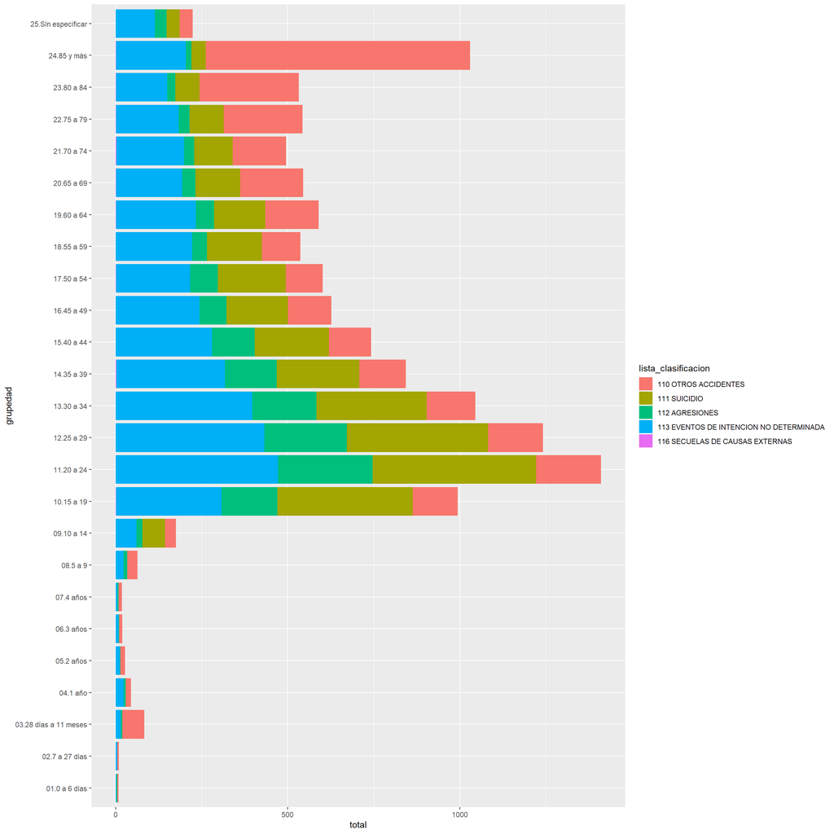

```r
plot_2019 <- ggplot(prueba, aes(grupedad, porc, colour = lista_clasificacion)) +
  geom_point() +
  coord_flip()
##AL DE ARRIBA LO HARIA MEJOR COMO BARRAS APILADAS
plot_2019 <- ggplot(prueba, aes(grupedad, porc, fill = lista_clasificacion)) +
geom_bar(position="fill", stat="identity")+
  coord_flip()

plot_2019 <- ggplot(prueba, aes(grupedad, total, fill = lista_clasificacion)) +
geom_bar(position="stack", stat="identity")+
  coord_flip()

plot_2019
```

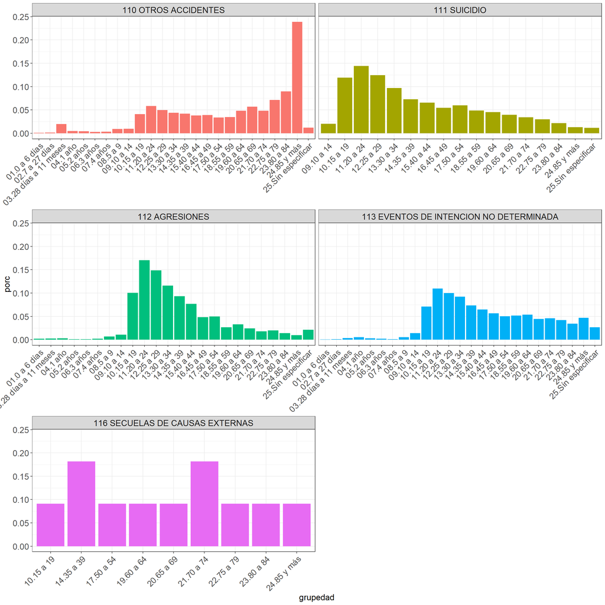

```r
##otro plot sugerido
# SE PODRIA AGRUPAR MENORES DE UN AÑO PARA CADA GRAFICO

ggplot(prueba2,
       aes(x = grupedad, y= porc, group = lista_clasificacion, fill = lista_clasificacion)) +
  geom_bar(stat="identity") +
  facet_wrap(vars(lista_clasificacion), scales="free_x", ncol=2)  +
  guides(fill=FALSE) + theme_bw() +
  theme(strip.text = element_text(size = 14),
        axis.text.x = element_text(angle = 45, hjust = 1),
        legend.title = element_blank(),
        axis.text = element_text(size = 14),
        axis.title = element_text(size = 14))
```

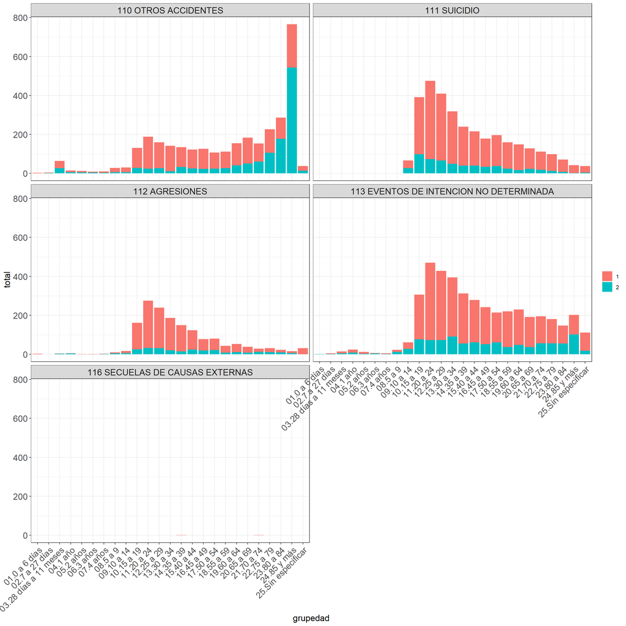

```r
ggplot(prueba_sexo,
       aes(x = grupedad, y= total, fill = as.factor(sexo))) +
  geom_bar(stat = "identity", position = "stack") +
  facet_wrap(~lista_clasificacion, ncol = 2 )  +
  theme_bw() +
  theme(strip.text = element_text(size = 14),
        axis.text.x = element_text(angle = 45, hjust = 1),
        legend.title = element_blank(),
        axis.text = element_text(size = 14),
        axis.title = element_text(size = 14))
```

### Descriptivo de causas externas de mortalidad en niños y adolescentes

```r
#filtro para grupo 10-29

str(mortalidad_2019)
```

```
## 'data.frame':    12447 obs. of  14 variables:
##  $ ano                           : int  2019 2019 2019 2019 2019 2019 2019 2019 2019 2019 ...
##  $ juri                          : int  2 2 2 2 2 2 2 2 2 2 ...
##  $ edad                          : int  49 77 38 27 55 34 80 24 32 36 ...
##  $ uniedad                       : int  1 1 1 1 1 1 1 1 1 1 ...
##  $ sexo                          : int  1 2 1 2 1 1 1 1 1 1 ...
##  $ grupedad                      : chr  "16.45 a 49" "22.75 a 79" "14.35 a 39" "12.25 a 29" ...
##  $ codmuer                       : chr  "Y200" "Y200" "X599" "Y218" ...
##  $ ocloc                         : int  4 3 3 4 2 3 3 4 1 1 ...
##  $ codmuer2                      : chr  "Y20" "Y20" "X59" "Y21" ...
##  $ No                            : num  13076 13076 12414 13087 12414 ...
##  $ Nombre                        : chr  "Ahorcamiento, estrangulamiento y sofocación, de intención no determinada" "Ahorcamiento, estrangulamiento y sofocación, de intención no determinada" "Exposición a factores no especificados" "Ahogamiento y sumersión, de intención no determinada" ...
##  $ Lista GBD  Grupos  (1,2, 3, 4): num  3 3 3 3 3 3 3 3 3 3 ...
##  $ Clave2                        : chr  "Y20" "Y20" "X59" "Y21" ...
##  $ lista_clasificacion           : chr  "113 EVENTOS DE INTENCION NO DETERMINADA" "113 EVENTOS DE INTENCION NO DETERMINADA" "110 OTROS ACCIDENTES" "113 EVENTOS DE INTENCION NO DETERMINADA" ...
```

```r
unique(mortalidad_2019$grupedad)
```

```
##  [1] "16.45 a 49"            "22.75 a 79"            "14.35 a 39"
##  [4] "12.25 a 29"            "18.55 a 59"            "13.30 a 34"
##  [7] "23.80 a 84"            "11.20 a 24"            "19.60 a 64"
## [10] "09.10 a 14"            "15.40 a 44"            "21.70 a 74"
## [13] "24.85 y más"           "20.65 a 69"            "10.15 a 19"
## [16] "17.50 a 54"            "08.5 a 9"              "04.1 año"
## [19] "25.Sín especificar"    "06.3 años"             "05.2 años"
## [22] "07.4 años"             "03.28 días a 11 meses" "02.7 a 27 días"
## [25] "01.0 a 6 días"
```

```r
nya <- c("12.25 a 29", "11.20 a 24", "09.10 a 14", "10.15 a 19")
sex <- c("1", "2")

mort_nya <- mortalidad_2019 %>%
  filter(grupedad %in% nya & sexo %in% sex) %>%
  group_by(grupedad, sexo, lista_clasificacion)%>%
  dplyr::summarise(total = n()) %>%
  ungroup() %>%
  group_by(grupedad) %>%
  mutate( porc = total/sum(total))
```

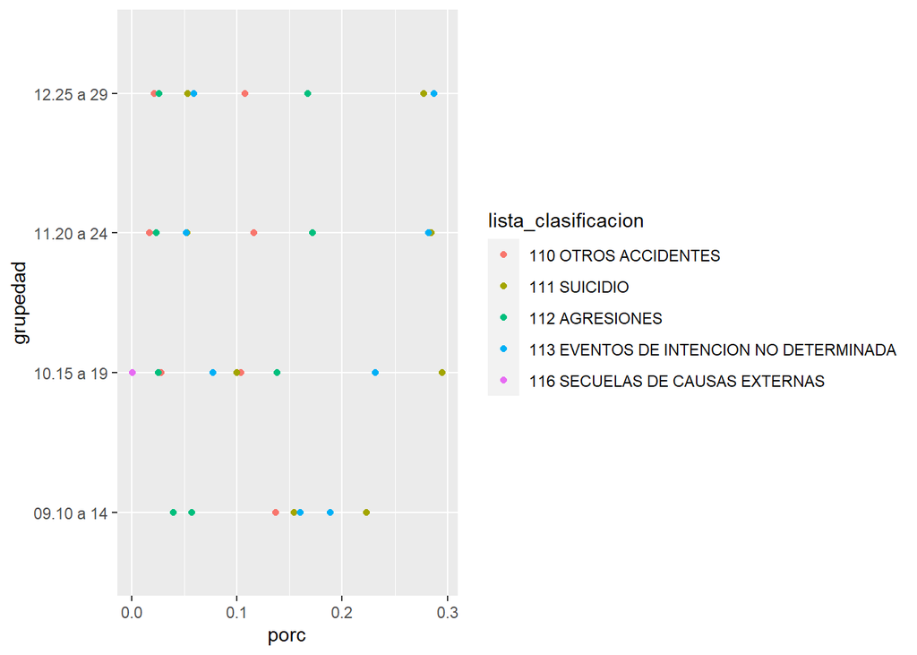

```r
plot_nya_2019 <- ggplot(mort_nya, aes(grupedad, porc, colour = lista_clasificacion)) +
  geom_point() +
  coord_flip()
plot_nya_2019
```

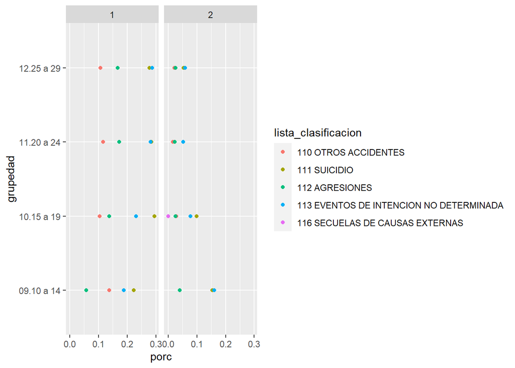

```r
##ver de mejorar estos graficos
##separo por sexo

#con facet grid
plot_nya_2019 <- ggplot(mort_nya, aes(grupedad, porc, colour = lista_clasificacion)) +
  geom_point() +
  facet_grid(~sexo)+
  coord_flip()
plot_nya_2019
```

```r
#con render

#install.packages("viridis")
library(viridis)
#install.packages("gganimate")
library(gganimate)
#install.packages("magick")
library(magick)
```

```r
graf_animado <- ggplot(mort_nya, aes(grupedad, porc, colour = lista_clasificacion)) +
  geom_point(size=5) +
  coord_flip() +
  scale_color_viridis(option = "mako", discrete = T, direction = -1)+
  theme_bw() +
  labs(caption = '{closest_state}', x = 'Casos confirmados', y = 'casos fallecidos', col="Grupo de edad:") +
  theme(text = element_text(colour = "#3D1308"),
        plot.caption = element_text(size = 14))  +
  transition_states(sexo,state_length=50)+
  #ease_aes('elastic-in')+
  shadow_wake(wake_length = 0.5,exclude_layer = 2)+
  guides(
  fill = guide_legend(
    override.aes = aes(label = "")
  )
)

graf_animado <- animate(graf_animado, renderer = magick_renderer())
```

## Mortalidad por agresiones en adolescentes

- Se calcula como número de muertes por agresiones entre 10 y 29 años. / población proyectada a mitad de periodo de 10 a 29 años , mismo año y provincia (evaluar dividir 10-19 y 20-29)
- Indicador para año 2019

```r
#recorte de proyecciones por edad y sexo

base_proyecciones <- read.csv2("poblacion indec gamma.csv", encoding="latin1", sep = ",")
#use doc de proyecciones gamma
str(base_proyecciones)
```

```
## 'data.frame':    864 obs. of  25 variables:
##  $ CodProv: int  2 2 2 2 2 2 2 2 2 2 ...
##  $ Ano    : int  2010 2010 2011 2011 2012 2012 2013 2013 2014 2014 ...
##  $ Sexo   : int  1 2 1 2 1 2 1 2 1 2 ...
##  $ Total  : int  1405566 1622915 1409835 1623804 1414105 1624755 1418339 1625737 1422507 1626722 ...
##  $ X0     : int  22150 20850 21372 20089 20771 19505 20655 19395 20925 19694 ...
##  $ X1.4   : int  87493 82621 87698 82718 87824 82781 87620 82572 87180 82153 ...
##  $ X5.9   : int  102701 98354 104496 99774 106030 100988 106597 101316 106372 100857 ...
##  $ X10.14 : int  95994 94500 95303 93350 95051 92628 95851 92922 97400 94002 ...
##  $ X15.19 : int  99784 101258 98932 99963 97944 98531 96818 96960 95665 95355 ...
##  $ X20.24 : int  111726 116572 109330 113937 106648 110889 104110 107904 102269 105602 ...
##  $ X25.29 : int  116490 122615 116655 122744 117073 123148 117246 123291 116485 122445 ...
##  $ X30.34 : int  117011 123148 117178 123221 116887 122912 116349 122399 115857 121920 ...
##  $ X35.39 : int  105455 112931 107828 115007 109799 116659 111330 117873 112414 118694 ...
##  $ X40.44 : int  85885 95002 88295 97287 91337 100213 94699 103449 97952 106534 ...
##  $ X45.49 : int  78726 90855 78758 90367 78941 90102 79438 90235 80461 90979 ...
##  $ X50.54 : int  76659 92557 76539 92005 76221 91164 75821 90183 75500 89266 ...
##  $ X55.59 : int  70233 88716 70650 89018 71187 89419 71739 89792 72153 89956 ...
##  $ X60.64 : int  63364 84016 63724 84385 63973 84585 64174 84693 64412 84813 ...
##  $ X65.69 : int  53532 75282 54207 76203 54889 77118 55541 77973 56133 78710 ...
##  $ X70.74 : int  42547 65286 43036 65923 43614 66671 44250 67500 44911 68380 ...
##  $ X75.79 : int  32679 56642 32410 56019 32387 55923 32565 56207 32881 56699 ...
##  $ X80.84 : int  24999 51842 24397 50359 23693 48546 23024 46750 22527 45341 ...
##  $ X85.89 : int  13286 32565 13639 33170 13932 33735 14118 34112 14153 34142 ...
##  $ X90.94 : int  3976 13091 4526 14002 4961 14777 5308 15440 5594 16025 ...
##  $ X95.   : int  876 4212 862 4263 943 4461 1086 4771 1263 5155 ...
```

```r
base_proyecciones_2019_nya <- base_proyecciones %>%
  filter(Ano == "2019") %>%
  select(CodProv, Sexo, X10.14, X15.19, X20.24, X25.29)

str(base_proyecciones_2019_nya)
```

```
## 'data.frame':    48 obs. of  6 variables:
##  $ CodProv: int  2 2 6 6 10 10 14 14 18 18 ...
##  $ Sexo   : int  1 2 1 2 1 2 1 2 1 2 ...
##  $ X10.14 : int  102793 97797 699226 659460 17638 16571 139573 132756 47256 44312 ...
##  $ X15.19 : int  95868 93172 667411 637569 19037 18069 141584 137612 48341 46304 ...
##  $ X20.24 : int  97401 98468 652019 633575 19040 18074 149097 146953 52616 51380 ...
##  $ X25.29 : int  104740 108977 667474 658052 16898 16116 150831 149076 47455 47819 ...
```

```r
agrup_base_proyecciones_2019_nya <- base_proyecciones_2019_nya %>%
  rowwise() %>%
  mutate("10_19" = sum(c(X10.14, X15.19))) %>%
  mutate("20_29" = sum(c(X20.24, X25.29))) %>%
  mutate(tot = sum(c(X10.14, X15.19, X20.24, X25.29)))

agrup_base_proyecciones_2019_nya_juntos <- agrup_base_proyecciones_2019_nya %>%
  pivot_wider(names_from = Sexo, values_from = c(X10.14, X15.19, X20.24, X25.29, `10_19`, `20_29`, tot))

total_nya <- agrup_base_proyecciones_2019_nya_juntos %>%
  rowwise() %>%
  mutate("total" = sum(c(tot_1, tot_2))) %>%
  select(CodProv, total)

#base mortalidad

str(mortalidad_2019)
```

```
## 'data.frame':    12447 obs. of  14 variables:
##  $ ano                           : int  2019 2019 2019 2019 2019 2019 2019 2019 2019 2019 ...
##  $ juri                          : int  2 2 2 2 2 2 2 2 2 2 ...
##  $ edad                          : int  49 77 38 27 55 34 80 24 32 36 ...
##  $ uniedad                       : int  1 1 1 1 1 1 1 1 1 1 ...
##  $ sexo                          : int  1 2 1 2 1 1 1 1 1 1 ...
##  $ grupedad                      : chr  "16.45 a 49" "22.75 a 79" "14.35 a 39" "12.25 a 29" ...
##  $ codmuer                       : chr  "Y200" "Y200" "X599" "Y218" ...
##  $ ocloc                         : int  4 3 3 4 2 3 3 4 1 1 ...
##  $ codmuer2                      : chr  "Y20" "Y20" "X59" "Y21" ...
##  $ No                            : num  13076 13076 12414 13087 12414 ...
##  $ Nombre                        : chr  "Ahorcamiento, estrangulamiento y sofocación, de intención no determinada" "Ahorcamiento, estrangulamiento y sofocación, de intención no determinada" "Exposición a factores no especificados" "Ahogamiento y sumersión, de intención no determinada" ...
##  $ Lista GBD  Grupos  (1,2, 3, 4): num  3 3 3 3 3 3 3 3 3 3 ...
##  $ Clave2                        : chr  "Y20" "Y20" "X59" "Y21" ...
##  $ lista_clasificacion           : chr  "113 EVENTOS DE INTENCION NO DETERMINADA" "113 EVENTOS DE INTENCION NO DETERMINADA" "110 OTROS ACCIDENTES" "113 EVENTOS DE INTENCION NO DETERMINADA" ...
```

```r
unique(mortalidad_2019$grupedad)
```

```
##  [1] "16.45 a 49"            "22.75 a 79"            "14.35 a 39"
##  [4] "12.25 a 29"            "18.55 a 59"            "13.30 a 34"
##  [7] "23.80 a 84"            "11.20 a 24"            "19.60 a 64"
## [10] "09.10 a 14"            "15.40 a 44"            "21.70 a 74"
## [13] "24.85 y más"           "20.65 a 69"            "10.15 a 19"
## [16] "17.50 a 54"            "08.5 a 9"              "04.1 año"
## [19] "25.Sín especificar"    "06.3 años"             "05.2 años"
## [22] "07.4 años"             "03.28 días a 11 meses" "02.7 a 27 días"
## [25] "01.0 a 6 días"
```

```r
nya <- c("12.25 a 29", "11.20 a 24", "09.10 a 14", "10.15 a 19")
sex <- c("1", "2")

mort_nya <- mortalidad_2019 %>%
  filter(grupedad %in% nya & sexo %in% sex) %>%
  group_by(juri, grupedad, sexo, lista_clasificacion)%>%
  dplyr::summarise(total = n())
#tomamos por un lado agresiones y por otro lado suicidios
mort_nya_suicidios <- mort_nya %>%
  filter(lista_clasificacion == "111 SUICIDIO") %>%
  group_by(juri) %>%
  summarise(tot_suicidios= sum(total))#agregre el tot

mort_nya_agresiones <- mort_nya %>%
  filter(lista_clasificacion == "112 AGRESIONES") %>%
  group_by(juri) %>%
  summarise(tot_agresiones=sum(total))

ind_mortalidad_suicidios <- left_join(mort_nya_suicidios, total_nya,
              by = c("juri" = "CodProv")) %>%
  mutate(ind = round(tot_suicidios/total* 100000,2))#corregí y agregue factor de expansion

ind_mortalidad_agresiones <- left_join(mort_nya_agresiones, total_nya,
              by = c("juri" = "CodProv")) %>%
  mutate(ind = round(tot_agresiones/total* 100000,2))

##aca armar tablas con datatable con los dos indicadores en una misma tabla


###revise hasta aca (velen)

#write_xlsx(ind_mortalidad_suicidios,"ind_mortalidad_suicidios.xlsx")
#write_xlsx(ind_mortalidad_agresiones,"ind_mortalidad_agresiones.xlsx")
```

```r
base_mortalidad <- read.csv2("MINSAL-defunciones-2005-2020.csv", encoding="latin1", sep = ",")
str(base_mortalidad)
```

```
## 'data.frame':    734616 obs. of  11 variables:
##  $ anio                         : int  2007 2012 2009 2014 2012 2012 2011 2013 2011 2009 ...
##  $ jurisdiccion_de_residencia_id: int  10 14 18 10 18 14 2 6 2 18 ...
##  $ jurisdicion_residencia_nombre: chr  "Catamarca" "Córdoba" "Corrientes" "Catamarca" ...
##  $ cie10_casusa_id              : chr  "V13" "C34" "K70" "N19" ...
##  $ lista_clasificacion          : chr  "105 ACCIDENTES DE TRANSPORTE" "034 TUMOR MALIGNO DE LA TRAQUEA,  DE LOS BRONQUIOS Y DEL PULMON" "084 ENFERMEDAD ALCOHOLICA DEL HIGADO" "090 ENFERMEDADES RENALES Y DEL URETER" ...
##  $ sexo_id                      : int  1 1 1 1 1 1 1 1 1 1 ...
##  $ Sexo                         : chr  "masculino" "masculino" "masculino" "masculino" ...
##  $ grupo_edad                   : chr  "04.15 a 24" "10.75 y más" "09.65 a 74" "09.65 a 74" ...
##  $ muerte_materna_id            : chr  "" "" "" "" ...
##  $ muerte_materna_clasificacion : chr  NA NA NA NA ...
##  $ cantidad                     : int  1 5 2 5 1 1 1 2 13 1 ...
```

```r
unique(base_mortalidad$lista_clasificacion)
```

```
##   [1] "105 ACCIDENTES DE TRANSPORTE"
##   [2] "034 TUMOR MALIGNO DE LA TRAQUEA,  DE LOS BRONQUIOS Y DEL PULMON"
##   [3] "084 ENFERMEDAD ALCOHOLICA DEL HIGADO"
##   [4] "090 ENFERMEDADES RENALES Y DEL URETER"
##   [5] "020 ENFERMEDAD POR VIRUS DE INMUNODEFICIENCIA HUMANA"
##   [6] "072 ENFERMEDADES DE LAS ARTERIAS, ARTERIOLAS Y VASOS CAPILARES"
##   [7] "071 ENFERMEDADES CEREBROVASCULARES"
##   [8] "085 OTRAS ENFERMEDADES DEL HIGADO"
##   [9] "070 OTRAS FORMAS DE ENFERMEDADES DEL CORAZON"
##  [10] "087 ENFERMEDADES DE LA PIEL Y DEL TEJIDO SUBCUTANEO"
##  [11] "047 OTROS TUMORES MALIGNOS DEL TEJIDO LINFATICO, ORGANOS  HEMATOPOYETICOS Y TEJIDOS AFINES"
##  [12] "106 AHOGAMIENTO ACCIDENTAL"
##  [13] "005 TUBERCULOSIS,  OTRAS FORMAS"
##  [14] "086 RESTO ENFERMEDADES DEL SISTEMA DIGESTIVO"
##  [15] "068 ENFERMEDAD CARDIOPULMONAR Y DE LA CIRCULACION PULMONAR"
```

[output cut: 99 more lines]

```r
#cod diabetes tipo 2: 053, pero no diferencia tipo 1 o 2

base_diabetes_2019 <- base_mortalidad %>%
  filter (lista_clasificacion == "053 DIABETES MELLITUS" & anio == "2019")

unique(base_mortalidad$grupo_edad)
```

```
##  [1] "04.15 a 24"          "10.75 y más"         "09.65 a 74"
##  [4] "11.Sín especificar"  "07.45 a 54"          "06.35 a 44"
##  [7] "08.55 a 64"          "01.Menores de 1 año" "05.25 a 34"
## [10] "02.1 a 4"            "03.5 a 14"
```

```r
base_diabetes_2019_adultos <- base_diabetes_2019 %>%
  filter (grupo_edad   == "10.75 y más" | grupo_edad == "09.65 a 74" | grupo_edad == "07.45 a 54" | grupo_edad == "06.35 a 44" | grupo_edad == "08.55 a 64" | grupo_edad == "05.25 a 34")

unique(base_diabetes_2019$cie10_casusa_id)
```

```
## [1] "E11" "E14" "E10" "E12" "E13"
```

```r
#hay E10 E11 E12 E13 E14

des_diabetes_2019 <- base_diabetes_2019_adultos %>%
  group_by(jurisdicion_residencia_nombre, cie10_casusa_id, grupo_edad, sexo_id) %>%
  dplyr::summarise(casos=sum(cantidad))
```

[output not shown]

```r
des_diabetes_2019_bis <- base_diabetes_2019_adultos %>%
  group_by(cie10_casusa_id, grupo_edad, sexo_id) %>%
  dplyr::summarise(casos=sum(cantidad))
```

```r
plot  <- des_diabetes_2019_bis %>%
  ggplot(aes(x = cie10_casusa_id,
             y = casos,
             color = sexo_id)) +
  geom_boxplot()

#  facet_grid(jurisdicion_residencia_nombre ~ .)
```